# Carregando Pacotes

```r
library(tidyverse) # data science
library(plotly) # interactive data visualization
library(naniar) # visualize missing data
library(mice) # imputação de dados ausentes
library(scorecard) # discretização de variáveis (muito utilizado em modelos de score de crédito)
library(caret) # machine learning (r base)
library(cvms) # visualização - matriz de confusão mais elegante
```

# Leitura de funções

```r
source(paste0(getwd(),'/funcoes/tabela_metadados.R'),encoding='utf-8')
source(paste0(getwd(),'/funcoes/funcoes_analiseunivariada.R'),encoding='utf-8')
source(paste0(getwd(),'/funcoes/funcoes_analisebivariada.R'),encoding='utf-8')
```

```r
options(digits = 3)
options(max.print = 50)

options(repr.matrix.max.rows = 15)
#options(repr.matrix.max.cols = 30)
```

# Importando os dados, juntando as tabelas e pré-processamento

```r
#setwd("C:/Users/joaom/OneDrive/JM/Projetos_Extracurriculares/Kaggle/Titanic")
getwd()
options(scipen=999,digits=10)
train <- read.csv("../../train.csv",
                  sep=",", stringsAsFactors = FALSE,
                  na.strings = "")
test <- read.csv("../../test.csv",
                 sep=",", stringsAsFactors = FALSE,
                 na.strings = "")
dim(train)
dim(test)
dim(train)[1]+dim(test)[1]
```

'c:/Users/joaom/OneDrive/JM/Projetos_Extracurriculares/Kaggle/Titanic/R/Titanic-Kaggle-R'

1. 891

2. 12

1. 418

2. 11

1309

```r
train['Sample'] <- as.factor('train')

test['Survived'] <- NA
test['Sample'] <- as.factor('test')

test <- test[colnames(train)]
```

```r
df <- rbind(train,test)
df %>% dim()
```

1. 1309

2. 13

```r
df[['PassengerId']] <- as.factor(df[['PassengerId']])
df[['Survived']] <- relevel(as.factor(df[['Survived']]),"1")
df[['Pclass']] <- factor(df[['Pclass']],ordered=TRUE)
df[['Sex']] <- as.factor(df[['Sex']])
df[['Cabin']] <- as.factor(df[['Cabin']])
df[['Embarked']] <- as.factor(df[['Embarked']])
```

# Tabela de Metadados

```r
str(df)
```

```
'data.frame':	1309 obs. of  13 variables:
 $ PassengerId: Factor w/ 1309 levels "1","2","3","4",..: 1 2 3 4 5 6 7 8 9 10 ...
 $ Survived   : Factor w/ 2 levels "1","0": 2 1 1 1 2 2 2 2 1 1 ...
 $ Pclass     : Ord.factor w/ 3 levels "1"<"2"<"3": 3 1 3 1 3 3 1 3 3 2 ...
 $ Name       : chr  "Braund, Mr. Owen Harris" "Cumings, Mrs. John Bradley (Florence Briggs Thayer)" "Heikkinen, Miss. Laina" "Futrelle, Mrs. Jacques Heath (Lily May Peel)" ...
 $ Sex        : Factor w/ 2 levels "female","male": 2 1 1 1 2 2 2 2 1 1 ...
 $ Age        : num  22 38 26 35 35 NA 54 2 27 14 ...
 $ SibSp      : int  1 1 0 1 0 0 0 3 0 1 ...
 $ Parch      : int  0 0 0 0 0 0 0 1 2 0 ...
 $ Ticket     : chr  "A/5 21171" "PC 17599" "STON/O2. 3101282" "113803" ...
 $ Fare       : num  7.25 71.28 7.92 53.1 8.05 ...
 $ Cabin      : Factor w/ 186 levels "A10","A11","A14",..: NA 107 NA 71 NA NA 164 NA NA NA ...
 $ Embarked   : Factor w/ 3 levels "C","Q","S": 3 1 3 3 3 2 3 3 3 1 ...
 $ Sample     : Factor w/ 2 levels "train","test": 1 1 1 1 1 1 1 1 1 1 ...
```

```r
glimpse(df)
```

```
Rows: 1,309
Columns: 13
$ PassengerId <fct> 1, 2, 3, 4, 5, 6, 7, 8, 9, 10, 11, 12, 13, 14, 15, 16, 17,~
$ Survived    <fct> 0, 1, 1, 1, 0, 0, 0, 0, 1, 1, 1, 1, 0, 0, 0, 1, 0, 1, 0, 1~
$ Pclass      <ord> 3, 1, 3, 1, 3, 3, 1, 3, 3, 2, 3, 1, 3, 3, 3, 2, 3, 2, 3, 3~
$ Name        <chr> "Braund, Mr. Owen Harris", "Cumings, Mrs. John Bradley (Fl~
$ Sex         <fct> male, female, female, female, male, male, male, male, fema~
$ Age         <dbl> 22, 38, 26, 35, 35, NA, 54, 2, 27, 14, 4, 58, 20, 39, 14, ~
$ SibSp       <int> 1, 1, 0, 1, 0, 0, 0, 3, 0, 1, 1, 0, 0, 1, 0, 0, 4, 0, 1, 0~
$ Parch       <int> 0, 0, 0, 0, 0, 0, 0, 1, 2, 0, 1, 0, 0, 5, 0, 0, 1, 0, 0, 0~
$ Ticket      <chr> "A/5 21171", "PC 17599", "STON/O2. 3101282", "113803", "37~
$ Fare        <dbl> 7.2500, 71.2833, 7.9250, 53.1000, 8.0500, 8.4583, 51.8625,~
$ Cabin       <fct> NA, C85, NA, C123, NA, NA, E46, NA, NA, NA, G6, C103, NA, ~
$ Embarked    <fct> S, C, S, S, S, Q, S, S, S, C, S, S, S, S, S, S, Q, S, S, C~
$ Sample      <fct> train, train, train, train, train, train, train, train, tr~
```

# Tabela de Metadados (Foco na Análise Exploratória e Tratamento dos dados)

```r
vector_vars_drop <- c('PassengerId','Name','Ticket','Sample')
```

```r
tabela_metadados(tabela_de_entrada = df[df[['Sample']] == 'train',],
                 sufixo_da_tabela_saida = 'df_train',
                 vector_vars_drop = vector_vars_drop)
```

1. 'Nome da tabela de entrada: df[df[["Sample"]] == "train", ]'

2. 'Dim da tabela de entrada: (891,13)'

3. 'Atributos a serem ignorados no futuro: c("PassengerId", "Name", "Ticket", "Sample")'

4. 'Nome da tabela abaixo: metadata_table_df_train'

5. A data.frame: 13 × 10

   | index <int> | columns <chr> | class <chr> | nunique <int> | nunique_with_na <int> | na_value_count <int> | p_na_value_count <dbl> | p_mode_value_natoo <dbl> | p_mode_value_notna <dbl> | drop <lgl> |
   | --- | --- | --- | --- | --- | --- | --- | --- | --- | --- |
   | 1 | PassengerId | factor | 891 | 891 | 0 | 0.000000000000 | 0.001122334456 | 0.001122334456 | TRUE |
   | 2 | Survived | factor | 2 | 2 | 0 | 0.000000000000 | 0.616161616162 | 0.616161616162 | FALSE |
   | 3 | Pclass | ordered; factor | 3 | 3 | 0 | 0.000000000000 | 0.551066217733 | 0.551066217733 | FALSE |
   | 4 | Name | character | 891 | 891 | 0 | 0.000000000000 | 0.001122334456 | 0.001122334456 | TRUE |
   | 5 | Sex | factor | 2 | 2 | 0 | 0.000000000000 | 0.647586980920 | 0.647586980920 | FALSE |
   | 6 | Age | numeric | 88 | 89 | 177 | 0.198653198653 | 0.198653198653 | 0.042016806723 | FALSE |
   | 7 | SibSp | integer | 7 | 7 | 0 | 0.000000000000 | 0.682379349046 | 0.682379349046 | FALSE |
   | 8 | Parch | integer | 7 | 7 | 0 | 0.000000000000 | 0.760942760943 | 0.760942760943 | FALSE |
   | 9 | Ticket | character | 681 | 681 | 0 | 0.000000000000 | 0.007856341190 | 0.007856341190 | TRUE |
   | 10 | Fare | numeric | 248 | 248 | 0 | 0.000000000000 | 0.048260381594 | 0.048260381594 | FALSE |
   | 11 | Cabin | factor | 147 | 148 | 687 | 0.771043771044 | 0.771043771044 | 0.019607843137 | FALSE |
   | 12 | Embarked | factor | 3 | 4 | 2 | 0.002244668911 | 0.722783389450 | 0.724409448819 | FALSE |
   | 13 | Sample | factor | 1 | 1 | 0 | 0.000000000000 | 1.000000000000 | 1.000000000000 | TRUE |

```r
tabela_metadados(tabela_de_entrada = df[df[['Sample']] == 'test',],
                 sufixo_da_tabela_saida = 'df_test',
                 vector_vars_drop = vector_vars_drop)
```

1. 'Nome da tabela de entrada: df[df[["Sample"]] == "test", ]'

2. 'Dim da tabela de entrada: (418,13)'

3. 'Atributos a serem ignorados no futuro: c("PassengerId", "Name", "Ticket", "Sample")'

4. 'Nome da tabela abaixo: metadata_table_df_test'

5. A data.frame: 13 × 10

   | index <int> | columns <chr> | class <chr> | nunique <int> | nunique_with_na <int> | na_value_count <int> | p_na_value_count <dbl> | p_mode_value_natoo <dbl> | p_mode_value_notna <dbl> | drop <lgl> |
   | --- | --- | --- | --- | --- | --- | --- | --- | --- | --- |
   | 1 | PassengerId | factor | 418 | 418 | 0 | 0.000000000000 | 0.002392344498 | 0.002392344498 | TRUE |
   | 2 | Survived | factor | 0 | 1 | 418 | 1.000000000000 | 1.000000000000 | Inf | FALSE |
   | 3 | Pclass | ordered; factor | 3 | 3 | 0 | 0.000000000000 | 0.521531100478 | 0.521531100478 | FALSE |
   | 4 | Name | character | 418 | 418 | 0 | 0.000000000000 | 0.002392344498 | 0.002392344498 | TRUE |
   | 5 | Sex | factor | 2 | 2 | 0 | 0.000000000000 | 0.636363636364 | 0.636363636364 | FALSE |
   | 6 | Age | numeric | 79 | 80 | 86 | 0.205741626794 | 0.205741626794 | 0.051204819277 | FALSE |
   | 7 | SibSp | integer | 7 | 7 | 0 | 0.000000000000 | 0.677033492823 | 0.677033492823 | FALSE |
   | 8 | Parch | integer | 8 | 8 | 0 | 0.000000000000 | 0.775119617225 | 0.775119617225 | FALSE |
   | 9 | Ticket | character | 363 | 363 | 0 | 0.000000000000 | 0.011961722488 | 0.011961722488 | TRUE |
   | 10 | Fare | numeric | 169 | 170 | 1 | 0.002392344498 | 0.050239234450 | 0.050359712230 | FALSE |
   | 11 | Cabin | factor | 76 | 77 | 327 | 0.782296650718 | 0.782296650718 | 0.032967032967 | FALSE |
   | 12 | Embarked | factor | 3 | 3 | 0 | 0.000000000000 | 0.645933014354 | 0.645933014354 | FALSE |
   | 13 | Sample | factor | 1 | 1 | 0 | 0.000000000000 | 1.000000000000 | 1.000000000000 | TRUE |

```r
tabela_metadados(tabela_de_entrada = df,
                 sufixo_da_tabela_saida = 'df',
                 vector_vars_drop = vector_vars_drop)
```

1. 'Nome da tabela de entrada: df'

2. 'Dim da tabela de entrada: (1309,13)'

3. 'Atributos a serem ignorados no futuro: c("PassengerId", "Name", "Ticket", "Sample")'

4. 'Nome da tabela abaixo: metadata_table_df'

5. A data.frame: 13 × 10

   | index <int> | columns <chr> | class <chr> | nunique <int> | nunique_with_na <int> | na_value_count <int> | p_na_value_count <dbl> | p_mode_value_natoo <dbl> | p_mode_value_notna <dbl> | drop <lgl> |
   | --- | --- | --- | --- | --- | --- | --- | --- | --- | --- |
   | 1 | PassengerId | factor | 1309 | 1309 | 0 | 0.0000000000000 | 0.0007639419404 | 0.0007639419404 | TRUE |
   | 2 | Survived | factor | 2 | 3 | 418 | 0.3193277310924 | 0.4194041252865 | 0.6161616161616 | FALSE |
   | 3 | Pclass | ordered; factor | 3 | 3 | 0 | 0.0000000000000 | 0.5416348357525 | 0.5416348357525 | FALSE |
   | 4 | Name | character | 1307 | 1307 | 0 | 0.0000000000000 | 0.0015278838808 | 0.0015278838808 | TRUE |
   | 5 | Sex | factor | 2 | 2 | 0 | 0.0000000000000 | 0.6440030557678 | 0.6440030557678 | FALSE |
   | 6 | Age | numeric | 98 | 99 | 263 | 0.2009167303285 | 0.2009167303285 | 0.0449330783939 | FALSE |
   | 7 | SibSp | integer | 7 | 7 | 0 | 0.0000000000000 | 0.6806722689076 | 0.6806722689076 | FALSE |
   | 8 | Parch | integer | 8 | 8 | 0 | 0.0000000000000 | 0.7654698242934 | 0.7654698242934 | FALSE |
   | 9 | Ticket | character | 929 | 929 | 0 | 0.0000000000000 | 0.0084033613445 | 0.0084033613445 | TRUE |
   | 10 | Fare | numeric | 281 | 282 | 1 | 0.0007639419404 | 0.0458365164248 | 0.0458715596330 | FALSE |
   | 11 | Cabin | factor | 186 | 187 | 1014 | 0.7746371275783 | 0.7746371275783 | 0.0203389830508 | FALSE |
   | 12 | Embarked | factor | 3 | 4 | 2 | 0.0015278838808 | 0.6982429335371 | 0.6993114001530 | FALSE |
   | 13 | Sample | factor | 2 | 2 | 0 | 0.0000000000000 | 0.6806722689076 | 0.6806722689076 | TRUE |

# Análise Descritiva e Exploratória

## Análise de Dados Faltantes

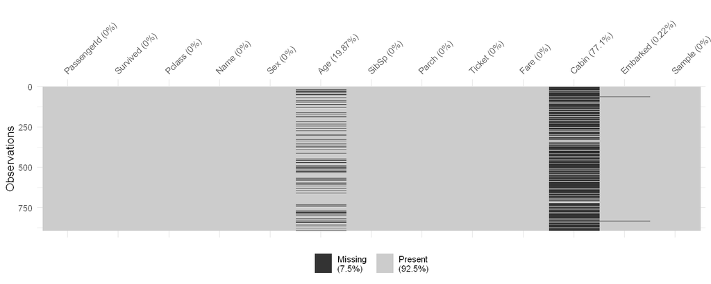

```r
naniar::vis_miss(df[df[['Sample']] == 'train',])
```

## Análise de Correlação

```r
table_train_for_cor <- df[ df[['Sample']] == 'train', metadata_table_df[metadata_table_df[['drop']] == FALSE, 'columns'] ]

# http://demosophy.org/heterogeneous-correlation-matrix/
rp_train <- polycor::hetcor(table_train_for_cor,std.err = FALSE,
                            use="pairwise.complete.obs",
                            pd=FALSE)
# rp_train[c('correlations','type')] # correlations e type (separados)
rp_train_modified <- rp_train[['correlations']]
rp_train_modified <- round(rp_train_modified,5)
rp_train_modified[upper.tri(rp_train_modified)] <- rp_train[['type']][upper.tri(rp_train_modified)]
```

```r
table_test_for_cor <- df[ df[['Sample']] == 'test', metadata_table_df[metadata_table_df[['drop']] == FALSE, 'columns'] ]

# http://demosophy.org/heterogeneous-correlation-matrix/
rp_test <- polycor::hetcor(table_test_for_cor,std.err = FALSE,
                            use="pairwise.complete.obs",
                            pd=FALSE)
# rp_test[c('correlations','type')] # correlations e type (separados)
rp_test_modified <- rp_test[['correlations']]
rp_test_modified <- round(rp_test_modified,5)
rp_test_modified[upper.tri(rp_test_modified)] <- rp_test[['type']][upper.tri(rp_test_modified)]
```

[output not shown]

```r
rp_train_modified
```

A matrix: 9 × 9 of type chr

|  | Survived | Pclass | Sex | Age | SibSp | Parch | Fare | Cabin | Embarked |
| --- | --- | --- | --- | --- | --- | --- | --- | --- | --- |
| Survived | 1 | Polychoric | Polychoric | Polyserial | Polyserial | Polyserial | Polyserial | Polychoric | Polychoric |
| Pclass | 0.48056 | 1 | Polychoric | Polyserial | Polyserial | Polyserial | Polyserial | Polychoric | Polychoric |
| Sex | 0.76091 | 0.19927 | 1 | Polyserial | Polyserial | Polyserial | Polyserial | Polychoric | Polychoric |
| Age | 0.09778 | -0.42742 | 0.11942 | 1 | Pearson | Pearson | Pearson | Polyserial | Polyserial |
| SibSp | 0.04498 | 0.09802 | -0.14748 | -0.30825 | 1 | Pearson | Pearson | Polyserial | Polyserial |
| Parch | -0.10395 | 0.02176 | -0.31583 | -0.18912 | 0.41484 | 1 | Pearson | Polyserial | Polyserial |
| Fare | -0.32765 | -0.64831 | -0.23458 | 0.09607 | 0.15965 | 0.21622 | 1 | Polyserial | Polyserial |
| Cabin | -0.0335 | 0.81259 | -0.12375 | -0.15648 | 0.06614 | 0.00919 | -0.2624 | 1 | Polychoric |
| Embarked | 0.26736 | 0.19344 | 0.18709 | -0.04508 | 0.09023 | 0.05297 | -0.29638 | 0.30712 | 1 |

```r
rp_test_modified
```

A matrix: 9 × 9 of type chr

|  | Survived | Pclass | Sex | Age | SibSp | Parch | Fare | Cabin | Embarked |
| --- | --- | --- | --- | --- | --- | --- | --- | --- | --- |
| Survived | 1 |  |  |  |  |  |  |  |  |
| Pclass | NA | 1 | Polychoric | Polyserial | Polyserial | Polyserial | Polyserial | Polychoric | Polychoric |
| Sex | NA | 0.15598 | 1 | Polyserial | Polyserial | Polyserial | Polyserial | Polychoric | Polychoric |
| Age | NA | -0.56235 | 0.00002 | 1 | Pearson | Pearson | Pearson | Polyserial | Polyserial |
| SibSp | NA | 0.00127 | -0.12807 | -0.09159 | 1 | Pearson | Pearson | Polyserial | Polyserial |
| Parch | NA | 0.02186 | -0.2039 | -0.06125 | 0.30689 | 1 | Pearson | Polyserial | Polyserial |
| Fare | NA | -0.67365 | -0.24534 | 0.33793 | 0.17154 | 0.23005 | 1 | Polyserial | Polyserial |
| Cabin | NA | 0.89534 | 0.03681 | -0.26728 | -0.09806 | -0.04412 | -0.23547 | 1 | Polychoric |
| Embarked | NA | 0.2764 | 0.13025 | -0.22579 | 0.06561 | 0.06794 | -0.32 | 0.11378 | 1 |

# Análise Univariada

## Sample

```r
calcula_tab_frequencia(tabela_de_entrada=df,
                        nome_variavel='Sample')
```

1. 'Nome da tabela abaixo: table_count_propSample'

2. A data.frame: 2 × 5

   | Category <fct> | Frequency <int> | Percentage <table> | Cumulative.Frequency <int> | Cumulative.Percentage <dbl> |
   | --- | --- | --- | --- | --- |
   | train | 891 | 68.07 | 891 | 68.07 |
   | test | 418 | 31.93 | 1309 | 100.00 |

```r
grafico_tab_frequencia(table_count_prop=table_count_propSample,
                        nome_variavel='Sample',
                        cor_grafico='black',
                        hjust_e=-0.08,hjust_d=0.08,
                        size=6,tx1=0.1,tx2=1.2)
gg_count_propSample <- gg_count_propSample + theme(axis.text=element_text(size=14),
                                                    axis.title=element_text(size=14))
gg_count_propSample_plotly <- ggplotly(gg_count_propSample)
```

1. 'Nome do gráfico: gg_count_propSample'

```r
htmlwidgets::saveWidget(as_widget(gg_count_propSample_plotly), "gg_count_propSample_plotly.html")
IRdisplay::display_html('<iframe src="gg_count_propSample_plotly.html" width=100%, height=400></iframe>')
```

[interactive chart not shown]

## Survived (Resposta)

```r
calcula_tab_frequencia(tabela_de_entrada=df[df[['Sample']] == 'train',],
                        nome_variavel='Survived')
```

1. 'Nome da tabela abaixo: table_count_propSurvived'

2. A data.frame: 2 × 5

   | Category <fct> | Frequency <int> | Percentage <table> | Cumulative.Frequency <int> | Cumulative.Percentage <dbl> |
   | --- | --- | --- | --- | --- |
   | 1 | 342 | 38.38 | 342 | 38.38 |
   | 0 | 549 | 61.62 | 891 | 100.00 |

```r
grafico_tab_frequencia(table_count_prop=table_count_propSurvived,
                        nome_variavel='Survived',
                        cor_grafico='blue',
                        hjust_e=-0.08,hjust_d=0.08,
                        size=6,tx1=0.1,tx2=1.05)
gg_count_propSurvived <- gg_count_propSurvived + theme(axis.text=element_text(size=14),
                                                    axis.title=element_text(size=14))
gg_count_propSurvived_plotly <- ggplotly(gg_count_propSurvived)
```

1. 'Nome do gráfico: gg_count_propSurvived'

```r
htmlwidgets::saveWidget(as_widget(gg_count_propSurvived_plotly), "gg_count_propSurvived_plotly.html")
IRdisplay::display_html('<iframe src="gg_count_propSurvived_plotly.html" width=100%, height=400></iframe>')
```

[interactive chart not shown]

# Análise Univariada e Bivariada

## Pclass

```r
calcula_tab_frequencia(tabela_de_entrada=df[df[['Sample']] == 'train',],
                        nome_variavel='Pclass')
```

1. 'Nome da tabela abaixo: table_count_propPclass'

2. A data.frame: 3 × 5

   | Category <fct> | Frequency <int> | Percentage <table> | Cumulative.Frequency <int> | Cumulative.Percentage <dbl> |
   | --- | --- | --- | --- | --- |
   | 1 | 216 | 24.24 | 216 | 24.24 |
   | 2 | 184 | 20.65 | 400 | 44.89 |
   | 3 | 491 | 55.11 | 891 | 100.00 |

```r
grafico_tab_frequencia(table_count_prop=table_count_propPclass,
                        nome_variavel='Pclass',
                        cor_grafico='red',
                        hjust_e=-0.12,hjust_d=0.12,
                        size=5.5,tx1=0.1,tx2=1.05)
gg_count_propPclass <- gg_count_propPclass + theme(axis.text=element_text(size=14),
                                                    axis.title=element_text(size=14))
gg_count_propPclass_plotly <- ggplotly(gg_count_propPclass)
```

1. 'Nome do gráfico: gg_count_propPclass'

```r
htmlwidgets::saveWidget(as_widget(gg_count_propPclass_plotly), "gg_count_propPclass_plotly.html")
IRdisplay::display_html('<iframe src="gg_count_propPclass_plotly.html" width=100%, height=400></iframe>')
```

[interactive chart not shown]

## Survived x Pclass

```r
calcula_tab_frequencia_bivariada(tabela_de_entrada=df[df[['Sample']] == 'train',],
                                 nome_variavel1='Survived',
                                 nome_variavel2='Pclass')
```

1. 'Nome da tabela abaixo: table_count_propSurvived_Pclass'

2. A data.frame: 6 × 8

   | Survived <fct> | Pclass <fct> | Frequency <int> | sum_x <int> | cumsum_sum_x <int> | percentage_sum_x <dbl> | Frequency_div_sum_x <dbl> | percentage_Frequency_div_sum_x <dbl> |
   | --- | --- | --- | --- | --- | --- | --- | --- |
   | 1 | 1 | 136 | 216 | 216 | 24.2 | 0.6296296296 | 63.0 |
   | 0 | 1 | 80 | 216 | 216 | 24.2 | 0.3703703704 | 37.0 |
   | 1 | 2 | 87 | 184 | 400 | 20.7 | 0.4728260870 | 47.3 |
   | 0 | 2 | 97 | 184 | 400 | 20.7 | 0.5271739130 | 52.7 |
   | 1 | 3 | 119 | 491 | 891 | 55.1 | 0.2423625255 | 24.2 |
   | 0 | 3 | 372 | 491 | 891 | 55.1 | 0.7576374745 | 75.8 |

```r
grafico_tab_frequencia_bivariada2(table_count_prop=table_count_propSurvived_Pclass,
                                  nome_variavel1='Survived',
                                  nome_variavel2='Pclass',
                                  tx1=0.2,tx2=1.1,size=6,legend=TRUE)

gg_count_propSurvived_Pclass <- gg_count_propSurvived_Pclass + theme(axis.text=element_text(size=15),
                                                                axis.title=element_text(size=15),
                                                                legend.title=element_text(size=15),
                                                                legend.text=element_text(size=15)) +
                                                                scale_fill_brewer(palette="Set2")
gg_count_propSurvived_Pclass_plotly1 <- ggplotly(gg_count_propSurvived_Pclass)
```

```
[1] "Para retirar as porcentagens, use legend = FALSE ou size = 0!"
```

1. 'Nome do gráfico: gg_count_propSurvived_Pclass'

```r
htmlwidgets::saveWidget(as_widget(gg_count_propSurvived_Pclass_plotly1), "gg_count_propSurvived_Pclass_plotly1.html")
IRdisplay::display_html('<iframe src="gg_count_propSurvived_Pclass_plotly1.html" width=100%, height=400></iframe>')
```

[interactive chart not shown]

```r
grafico_tab_frequencia_bivariada3(table_count_prop=table_count_propSurvived_Pclass,
                                  nome_variavel1='Survived',
                                  nome_variavel2='Pclass',
                                  size=6,tx=0,legend=TRUE)
gg_count_propSurvived_Pclass <- gg_count_propSurvived_Pclass + theme(axis.text=element_text(size=15),
                                                                axis.title=element_text(size=15),
                                                                legend.title=element_text(size=15),
                                                                legend.text=element_text(size=15)) +
                                                                scale_fill_brewer(palette="Set2")
gg_count_propSurvived_Pclass_plotly2 <- ggplotly(gg_count_propSurvived_Pclass)
```

1. 'Nome do gráfico: gg_count_propSurvived_Pclass'

```r
htmlwidgets::saveWidget(as_widget(gg_count_propSurvived_Pclass_plotly2), "gg_count_propSurvived_Pclass_plotly2.html")
IRdisplay::display_html('<iframe src="gg_count_propSurvived_Pclass_plotly2.html" width=100%, height=400></iframe>')
```

[interactive chart not shown]

## Sex

```r
calcula_tab_frequencia(tabela_de_entrada=df[df[['Sample']] == 'train',],
                        nome_variavel='Sex')
```

1. 'Nome da tabela abaixo: table_count_propSex'

2. A data.frame: 2 × 5

   | Category <fct> | Frequency <int> | Percentage <table> | Cumulative.Frequency <int> | Cumulative.Percentage <dbl> |
   | --- | --- | --- | --- | --- |
   | female | 314 | 35.24 | 314 | 35.24 |
   | male | 577 | 64.76 | 891 | 100.00 |

```r
grafico_tab_frequencia(table_count_prop=table_count_propSex,
                        nome_variavel='Sex',
                        cor_grafico='darkgreen',
                        hjust_e=-0.09,hjust_d=0.09,
                        size=6.5,tx1=0.1,tx2=1.05)
gg_count_propSex <- gg_count_propSex + theme(axis.text=element_text(size=14),
                                            axis.title=element_text(size=14))
gg_count_propSex_plotly <- ggplotly(gg_count_propSex)
```

1. 'Nome do gráfico: gg_count_propSex'

```r
htmlwidgets::saveWidget(as_widget(gg_count_propSex_plotly), "gg_count_propSex_plotly.html")
IRdisplay::display_html('<iframe src="gg_count_propSex_plotly.html" width=100%, height=400></iframe>')
```

[interactive chart not shown]

## Survived x Sex

```r
calcula_tab_frequencia_bivariada(tabela_de_entrada=df[df[['Sample']] == 'train',],
                                 nome_variavel1='Survived',
                                 nome_variavel2='Sex')
```

1. 'Nome da tabela abaixo: table_count_propSurvived_Sex'

2. A data.frame: 4 × 8

   | Survived <fct> | Sex <fct> | Frequency <int> | sum_x <int> | cumsum_sum_x <int> | percentage_sum_x <dbl> | Frequency_div_sum_x <dbl> | percentage_Frequency_div_sum_x <dbl> |
   | --- | --- | --- | --- | --- | --- | --- | --- |
   | 1 | female | 233 | 314 | 314 | 35.2 | 0.7420382166 | 74.2 |
   | 0 | female | 81 | 314 | 314 | 35.2 | 0.2579617834 | 25.8 |
   | 1 | male | 109 | 577 | 891 | 64.8 | 0.1889081456 | 18.9 |
   | 0 | male | 468 | 577 | 891 | 64.8 | 0.8110918544 | 81.1 |

```r
grafico_tab_frequencia_bivariada2(table_count_prop=table_count_propSurvived_Sex,
                                  nome_variavel1='Survived',
                                  nome_variavel2='Sex',
                                  tx1=0.15,tx2=1.1,size=6,legend=TRUE)

gg_count_propSurvived_Sex <- gg_count_propSurvived_Sex + theme(axis.text=element_text(size=15),
                                                                axis.title=element_text(size=15),
                                                                legend.title=element_text(size=15),
                                                                legend.text=element_text(size=15)) +
                                                                scale_fill_brewer(palette="Set2")
gg_count_propSurvived_Sex_plotly1 <- ggplotly(gg_count_propSurvived_Sex)
```

```
[1] "Para retirar as porcentagens, use legend = FALSE ou size = 0!"
```

1. 'Nome do gráfico: gg_count_propSurvived_Sex'

```r
htmlwidgets::saveWidget(as_widget(gg_count_propSurvived_Sex_plotly1), "gg_count_propSurvived_Sex_plotly1.html")
IRdisplay::display_html('<iframe src="gg_count_propSurvived_Sex_plotly1.html" width=100%, height=400></iframe>')
```

[interactive chart not shown]

```r
grafico_tab_frequencia_bivariada3(table_count_prop=table_count_propSurvived_Sex,
                                  nome_variavel1='Survived',
                                  nome_variavel2='Sex',
                                  size=6,tx=0,legend=TRUE)
gg_count_propSurvived_Sex <- gg_count_propSurvived_Sex + theme(axis.text=element_text(size=15),
                                                                axis.title=element_text(size=15),
                                                                legend.title=element_text(size=15),
                                                                legend.text=element_text(size=15)) +
                                                                scale_fill_brewer(palette="Set2")
gg_count_propSurvived_Sex_plotly2 <- ggplotly(gg_count_propSurvived_Sex)
```

1. 'Nome do gráfico: gg_count_propSurvived_Sex'

```r
htmlwidgets::saveWidget(as_widget(gg_count_propSurvived_Sex_plotly2), "gg_count_propSurvived_Sex_plotly2.html")
IRdisplay::display_html('<iframe src="gg_count_propSurvived_Sex_plotly2.html" width=100%, height=400></iframe>')
```

[interactive chart not shown]

## SibSp

```r
calcula_tab_frequencia(tabela_de_entrada=df[df[['Sample']] == 'train',],
                        nome_variavel='SibSp')
```

1. 'Nome da tabela abaixo: table_count_propSibSp'

2. A data.frame: 7 × 5

   | Category <fct> | Frequency <int> | Percentage <table> | Cumulative.Frequency <int> | Cumulative.Percentage <dbl> |
   | --- | --- | --- | --- | --- |
   | 0 | 608 | 68.24 | 608 | 68.24 |
   | 1 | 209 | 23.46 | 817 | 91.69 |
   | 2 | 28 | 3.14 | 845 | 94.84 |
   | 3 | 16 | 1.80 | 861 | 96.63 |
   | 4 | 18 | 2.02 | 879 | 98.65 |
   | 5 | 5 | 0.56 | 884 | 99.21 |
   | 8 | 7 | 0.79 | 891 | 100.00 |

```r
grafico_tab_frequencia2(table_count_prop=table_count_propSibSp,
                        nome_variavel='SibSp',
                        cor_grafico='orange',
                        size=6.5,tx1=0.2,tx2=1.05,
                        coord_flip=FALSE)
gg_count_propSibSp <- gg_count_propSibSp + theme(axis.text=element_text(size=14),
                                            axis.title=element_text(size=14))
gg_count_propSibSp_plotly <- ggplotly(gg_count_propSibSp)
```

1. 'Nome do gráfico: gg_count_propSibSp'

```r
htmlwidgets::saveWidget(as_widget(gg_count_propSibSp_plotly), "gg_count_propSibSp_plotly.html")
IRdisplay::display_html('<iframe src="gg_count_propSibSp_plotly.html" width=100%, height=400></iframe>')
```

[interactive chart not shown]

## Survived x SibSp

```r
calcula_tab_frequencia_bivariada(tabela_de_entrada=df[df[['Sample']] == 'train',],
                                 nome_variavel1='Survived',
                                 nome_variavel2='SibSp')
```

1. 'Nome da tabela abaixo: table_count_propSurvived_SibSp'

2. A data.frame: 14 × 8

   | Survived <fct> | SibSp <fct> | Frequency <int> | sum_x <int> | cumsum_sum_x <int> | percentage_sum_x <dbl> | Frequency_div_sum_x <dbl> | percentage_Frequency_div_sum_x <dbl> |
   | --- | --- | --- | --- | --- | --- | --- | --- |
   | 1 | 0 | 210 | 608 | 608 | 68.2 | 0.3453947368 | 34.5 |
   | 0 | 0 | 398 | 608 | 608 | 68.2 | 0.6546052632 | 65.5 |
   | 1 | 1 | 112 | 209 | 817 | 23.5 | 0.5358851675 | 53.6 |
   | 0 | 1 | 97 | 209 | 817 | 23.5 | 0.4641148325 | 46.4 |
   | 1 | 2 | 13 | 28 | 845 | 3.1 | 0.4642857143 | 46.4 |
   | 0 | 2 | 15 | 28 | 845 | 3.1 | 0.5357142857 | 53.6 |
   | 1 | 3 | 4 | 16 | 861 | 1.8 | 0.2500000000 | 25.0 |
   | 0 | 3 | 12 | 16 | 861 | 1.8 | 0.7500000000 | 75.0 |
   | 1 | 4 | 3 | 18 | 879 | 2.0 | 0.1666666667 | 16.7 |
   | 0 | 4 | 15 | 18 | 879 | 2.0 | 0.8333333333 | 83.3 |
   | 1 | 5 | 0 | 5 | 884 | 0.6 | 0.0000000000 | 0.0 |
   | 0 | 5 | 5 | 5 | 884 | 0.6 | 1.0000000000 | 100.0 |
   | 1 | 8 | 0 | 7 | 891 | 0.8 | 0.0000000000 | 0.0 |
   | 0 | 8 | 7 | 7 | 891 | 0.8 | 1.0000000000 | 100.0 |

```r
grafico_tab_frequencia_bivariada2(table_count_prop=table_count_propSurvived_SibSp,
                                  nome_variavel1='Survived',
                                  nome_variavel2='SibSp',
                                  tx1=0.5,tx2=1,size=4.8,
                                  legend=TRUE,percentage=TRUE,count=FALSE)

gg_count_propSurvived_SibSp <- gg_count_propSurvived_SibSp + theme(axis.text=element_text(size=15),
                                                                axis.title=element_text(size=15),
                                                                legend.title=element_text(size=15),
                                                                legend.text=element_text(size=15)) +
                                                                scale_fill_brewer(palette="Set2")
gg_count_propSurvived_SibSp_plotly1 <- ggplotly(gg_count_propSurvived_SibSp)
```

```
[1] "Para retirar as porcentagens, use legend = FALSE ou size = 0!"
```

1. 'Nome do gráfico: gg_count_propSurvived_SibSp'

```r
htmlwidgets::saveWidget(as_widget(gg_count_propSurvived_SibSp_plotly1), "gg_count_propSurvived_SibSp_plotly1.html")
IRdisplay::display_html('<iframe src="gg_count_propSurvived_SibSp_plotly1.html" width=100%, height=400></iframe>')
```

[interactive chart not shown]

```r
grafico_tab_frequencia_bivariada3(table_count_prop=table_count_propSurvived_SibSp,
                                  nome_variavel1='Survived',
                                  nome_variavel2='SibSp',
                                  size=6,tx=0,legend=TRUE)
gg_count_propSurvived_SibSp <- gg_count_propSurvived_SibSp + theme(axis.text=element_text(size=15),
                                                                axis.title=element_text(size=15),
                                                                legend.title=element_text(size=15),
                                                                legend.text=element_text(size=15)) +
                                                                scale_fill_brewer(palette="Set2")
gg_count_propSurvived_SibSp_plotly2 <- ggplotly(gg_count_propSurvived_SibSp)
```

1. 'Nome do gráfico: gg_count_propSurvived_SibSp'

```r
htmlwidgets::saveWidget(as_widget(gg_count_propSurvived_SibSp_plotly2), "gg_count_propSurvived_SibSp_plotly2.html")
IRdisplay::display_html('<iframe src="gg_count_propSurvived_SibSp_plotly2.html" width=100%, height=400></iframe>')
```

[interactive chart not shown]

## Parch

```r
calcula_tab_frequencia(tabela_de_entrada=df[df[['Sample']] == 'train',],
                        nome_variavel='Parch')
```

1. 'Nome da tabela abaixo: table_count_propParch'

2. A data.frame: 7 × 5

   | Category <fct> | Frequency <int> | Percentage <table> | Cumulative.Frequency <int> | Cumulative.Percentage <dbl> |
   | --- | --- | --- | --- | --- |
   | 0 | 678 | 76.09 | 678 | 76.09 |
   | 1 | 118 | 13.24 | 796 | 89.34 |
   | 2 | 80 | 8.98 | 876 | 98.32 |
   | 3 | 5 | 0.56 | 881 | 98.88 |
   | 4 | 4 | 0.45 | 885 | 99.33 |
   | 5 | 5 | 0.56 | 890 | 99.89 |
   | 6 | 1 | 0.11 | 891 | 100.00 |

```r
grafico_tab_frequencia2(table_count_prop=table_count_propParch,
                        nome_variavel='Parch',
                        cor_grafico='purple',
                        size=6.5,tx1=0.4,tx2=1.05,
                        coord_flip=FALSE)
gg_count_propParch <- gg_count_propParch + theme(axis.text=element_text(size=14),
                                            axis.title=element_text(size=14))
gg_count_propParch_plotly <- ggplotly(gg_count_propParch)
```

1. 'Nome do gráfico: gg_count_propParch'

```r
htmlwidgets::saveWidget(as_widget(gg_count_propParch_plotly), "gg_count_propParch_plotly.html")
IRdisplay::display_html('<iframe src="gg_count_propParch_plotly.html" width=100%, height=400></iframe>')
```

[interactive chart not shown]

## Survived x Parch

```r
calcula_tab_frequencia_bivariada(tabela_de_entrada=df[df[['Sample']] == 'train',],
                                 nome_variavel1='Survived',
                                 nome_variavel2='Parch')
```

1. 'Nome da tabela abaixo: table_count_propSurvived_Parch'

2. A data.frame: 14 × 8

   | Survived <fct> | Parch <fct> | Frequency <int> | sum_x <int> | cumsum_sum_x <int> | percentage_sum_x <dbl> | Frequency_div_sum_x <dbl> | percentage_Frequency_div_sum_x <dbl> |
   | --- | --- | --- | --- | --- | --- | --- | --- |
   | 1 | 0 | 233 | 678 | 678 | 76.1 | 0.3436578171 | 34.4 |
   | 0 | 0 | 445 | 678 | 678 | 76.1 | 0.6563421829 | 65.6 |
   | 1 | 1 | 65 | 118 | 796 | 13.2 | 0.5508474576 | 55.1 |
   | 0 | 1 | 53 | 118 | 796 | 13.2 | 0.4491525424 | 44.9 |
   | 1 | 2 | 40 | 80 | 876 | 9.0 | 0.5000000000 | 50.0 |
   | 0 | 2 | 40 | 80 | 876 | 9.0 | 0.5000000000 | 50.0 |
   | 1 | 3 | 3 | 5 | 881 | 0.6 | 0.6000000000 | 60.0 |
   | 0 | 3 | 2 | 5 | 881 | 0.6 | 0.4000000000 | 40.0 |
   | 1 | 4 | 0 | 4 | 885 | 0.4 | 0.0000000000 | 0.0 |
   | 0 | 4 | 4 | 4 | 885 | 0.4 | 1.0000000000 | 100.0 |
   | 1 | 5 | 1 | 5 | 890 | 0.6 | 0.2000000000 | 20.0 |
   | 0 | 5 | 4 | 5 | 890 | 0.6 | 0.8000000000 | 80.0 |
   | 1 | 6 | 0 | 1 | 891 | 0.1 | 0.0000000000 | 0.0 |
   | 0 | 6 | 1 | 1 | 891 | 0.1 | 1.0000000000 | 100.0 |

```r
grafico_tab_frequencia_bivariada2(table_count_prop=table_count_propSurvived_Parch,
                                  nome_variavel1='Survived',
                                  nome_variavel2='Parch',
                                  tx1=0.3,tx2=0.7,size=4.8,
                                  legend=TRUE,percentage=TRUE,count=FALSE)

gg_count_propSurvived_Parch <- gg_count_propSurvived_Parch + theme(axis.text=element_text(size=15),
                                                                axis.title=element_text(size=15),
                                                                legend.title=element_text(size=15),
                                                                legend.text=element_text(size=15)) +
                                                                scale_fill_brewer(palette="Set2")
gg_count_propSurvived_Parch_plotly1 <- ggplotly(gg_count_propSurvived_Parch)
```

```
[1] "Para retirar as porcentagens, use legend = FALSE ou size = 0!"
```

1. 'Nome do gráfico: gg_count_propSurvived_Parch'

```r
htmlwidgets::saveWidget(as_widget(gg_count_propSurvived_Parch_plotly1), "gg_count_propSurvived_Parch_plotly1.html")
IRdisplay::display_html('<iframe src="gg_count_propSurvived_Parch_plotly1.html" width=100%, height=400></iframe>')
```

[interactive chart not shown]

```r
grafico_tab_frequencia_bivariada3(table_count_prop=table_count_propSurvived_Parch,
                                  nome_variavel1='Survived',
                                  nome_variavel2='Parch',
                                  size=6,tx=0,legend=TRUE)
gg_count_propSurvived_Parch <- gg_count_propSurvived_Parch + theme(axis.text=element_text(size=15),
                                                                axis.title=element_text(size=15),
                                                                legend.title=element_text(size=15),
                                                                legend.text=element_text(size=15)) +
                                                                scale_fill_brewer(palette="Set2")
gg_count_propSurvived_Parch_plotly2 <- ggplotly(gg_count_propSurvived_Parch)
```

1. 'Nome do gráfico: gg_count_propSurvived_Parch'

```r
htmlwidgets::saveWidget(as_widget(gg_count_propSurvived_Parch_plotly2), "gg_count_propSurvived_Parch_plotly2.html")
IRdisplay::display_html('<iframe src="gg_count_propSurvived_Parch_plotly2.html" width=100%, height=400></iframe>')
```

[interactive chart not shown]

## Fare

```r
binning_quantities(dados_entrada=df[df[['Sample']] == 'train',],
                    nome_variavel='Fare',
                    method='Sturges')
```

1. 'Nome da lista: lista_Fare'

2. **$k**

   11

   **$limites_intervalos**

   1. -Inf

   2. 46.6

   3. 93.2

   4. 140

   5. 186

   6. 233

   7. 279

   8. 326

   9. 373

   10. 419

   11. 466

   12. Inf

   **$dados_saida**

   2. (46.6,93.2]

   3. (-Inf,46.6]

   4. (46.6,93.2]

   5. (-Inf,46.6]

   6. (-Inf,46.6]

   7. (46.6,93.2]

   8. (-Inf,46.6]

   9. (-Inf,46.6]

   10. (-Inf,46.6]

   11. (-Inf,46.6]

   12. (-Inf,46.6]

   13. (-Inf,46.6]

   14. (-Inf,46.6]

   15. (-Inf,46.6]

   16. (-Inf,46.6]

   17. (-Inf,46.6]

   18. (-Inf,46.6]

   19. (-Inf,46.6]

   20. (-Inf,46.6]

   21. (-Inf,46.6]

   22. (-Inf,46.6]

   23. (-Inf,46.6]

   24. (-Inf,46.6]

   25. (-Inf,46.6]

   26. (-Inf,46.6]

   27. (-Inf,46.6]

   28. (233,279]

   29. (-Inf,46.6]

   30. (-Inf,46.6]

   31. (-Inf,46.6]

   32. (140,186]

   33. (-Inf,46.6]

   34. (-Inf,46.6]

   35. (46.6,93.2]

   36. (46.6,93.2]

   37. (-Inf,46.6]

   38. (-Inf,46.6]

   39. (-Inf,46.6]

   40. (-Inf,46.6]

   41. (-Inf,46.6]

   42. (-Inf,46.6]

   43. (-Inf,46.6]

   44. (-Inf,46.6]

   45. (-Inf,46.6]

   46. (-Inf,46.6]

   47. (-Inf,46.6]

   48. (-Inf,46.6]

   49. (-Inf,46.6]

   50. (-Inf,46.6]

   51. (-Inf,46.6]

   52. (-Inf,46.6]

   53. (46.6,93.2]

   54. (-Inf,46.6]

   55. (46.6,93.2]

   56. (-Inf,46.6]

   57. (-Inf,46.6]

   58. (-Inf,46.6]

   59. (-Inf,46.6]

   60. (46.6,93.2]

   61. (-Inf,46.6]

   62. (46.6,93.2]

   63. (46.6,93.2]

   64. (-Inf,46.6]

   65. (-Inf,46.6]

   66. (-Inf,46.6]

   67. (-Inf,46.6]

   68. (-Inf,46.6]

   69. (-Inf,46.6]

   70. (-Inf,46.6]

   71. (-Inf,46.6]

   72. (46.6,93.2]

   73. (46.6,93.2]

   74. (-Inf,46.6]

   75. (46.6,93.2]

   76. (-Inf,46.6]

   77. (-Inf,46.6]

   78. (-Inf,46.6]

   79. (-Inf,46.6]

   80. (-Inf,46.6]

   81. (-Inf,46.6]

   82. (-Inf,46.6]

   83. (-Inf,46.6]

   84. (46.6,93.2]

   85. (-Inf,46.6]

   86. (-Inf,46.6]

   87. (-Inf,46.6]

   88. (-Inf,46.6]

   89. (233,279]

   90. (-Inf,46.6]

   91. (-Inf,46.6]

   92. (-Inf,46.6]

   93. (46.6,93.2]

   94. (-Inf,46.6]

   95. (-Inf,46.6]

   96. (-Inf,46.6]

   97. (-Inf,46.6]

   98. (46.6,93.2]

   99. (-Inf,46.6]

   100. (-Inf,46.6]

   101. (-Inf,46.6]

   102. (-Inf,46.6]

   103. (46.6,93.2]

   104. (-Inf,46.6]

   105. (-Inf,46.6]

   106. (-Inf,46.6]

   107. (-Inf,46.6]

   108. (-Inf,46.6]

   109. (-Inf,46.6]

   110. (-Inf,46.6]

   111. (46.6,93.2]

   112. (-Inf,46.6]

   113. (-Inf,46.6]

   114. (-Inf,46.6]

   115. (-Inf,46.6]

   116. (-Inf,46.6]

   117. (-Inf,46.6]

   118. (-Inf,46.6]

   119. (233,279]

   120. (-Inf,46.6]

   121. (46.6,93.2]

   122. (-Inf,46.6]

   123. (-Inf,46.6]

   124. (-Inf,46.6]

   125. (46.6,93.2]

   126. (-Inf,46.6]

   127. (-Inf,46.6]

   128. (-Inf,46.6]

   129. (-Inf,46.6]

   130. (-Inf,46.6]

   131. (-Inf,46.6]

   132. (-Inf,46.6]

   133. (-Inf,46.6]

   134. (-Inf,46.6]

   135. (-Inf,46.6]

   136. (-Inf,46.6]

   137. (-Inf,46.6]

   138. (46.6,93.2]

   139. (-Inf,46.6]

   140. (46.6,93.2]

   141. (-Inf,46.6]

   142. (-Inf,46.6]

   143. (-Inf,46.6]

   144. (-Inf,46.6]

   145. (-Inf,46.6]

   146. (-Inf,46.6]

   147. (-Inf,46.6]

   148. (-Inf,46.6]

   149. (-Inf,46.6]

   150. (-Inf,46.6]

   151. (-Inf,46.6]

   152. (46.6,93.2]

   153. (-Inf,46.6]

   154. (-Inf,46.6]

   155. (-Inf,46.6]

   156. (46.6,93.2]

   157. (-Inf,46.6]

   158. (-Inf,46.6]

   159. (-Inf,46.6]

   160. (46.6,93.2]

   161. (-Inf,46.6]

   162. (-Inf,46.6]

   163. (-Inf,46.6]

   164. (-Inf,46.6]

   165. (-Inf,46.6]

   166. (-Inf,46.6]

   167. (46.6,93.2]

   168. (-Inf,46.6]

   169. (-Inf,46.6]

   170. (46.6,93.2]

   171. (-Inf,46.6]

   172. (-Inf,46.6]

   173. (-Inf,46.6]

   174. (-Inf,46.6]

   175. (-Inf,46.6]

   176. (-Inf,46.6]

   177. (-Inf,46.6]

   178. (-Inf,46.6]

   179. (-Inf,46.6]

   180. (-Inf,46.6]

   181. (46.6,93.2]

   182. (-Inf,46.6]

   183. (-Inf,46.6]

   184. (-Inf,46.6]

   185. (-Inf,46.6]

   186. (46.6,93.2]

   187. (-Inf,46.6]

   188. (-Inf,46.6]

   189. (-Inf,46.6]

   190. (-Inf,46.6]

   191. (-Inf,46.6]

   192. (-Inf,46.6]

   193. (-Inf,46.6]

   194. (-Inf,46.6]

   195. (-Inf,46.6]

   196. (140,186]

   197. (-Inf,46.6]

   198. (-Inf,46.6]

   199. (-Inf,46.6]

   200. (-Inf,46.6]

   201. ...

   202. (-Inf,46.6]

   203. (46.6,93.2]

   204. (-Inf,46.6]

   205. (-Inf,46.6]

   206. (-Inf,46.6]

   207. (-Inf,46.6]

   208. (-Inf,46.6]

   209. (93.2,140]

   210. (-Inf,46.6]

   211. (186,233]

   212. (-Inf,46.6]

   213. (-Inf,46.6]

   214. (-Inf,46.6]

   215. (-Inf,46.6]

   216. (-Inf,46.6]

   217. (-Inf,46.6]

   218. (-Inf,46.6]

   219. (140,186]

   220. (-Inf,46.6]

   221. (46.6,93.2]

   222. (-Inf,46.6]

   223. (46.6,93.2]

   224. (-Inf,46.6]

   225. (-Inf,46.6]

   226. (-Inf,46.6]

   227. (186,233]

   228. (-Inf,46.6]

   229. (-Inf,46.6]

   230. (-Inf,46.6]

   231. (-Inf,46.6]

   232. (-Inf,46.6]

   233. (-Inf,46.6]

   234. (-Inf,46.6]

   235. (46.6,93.2]

   236. (-Inf,46.6]

   237. (-Inf,46.6]

   238. (-Inf,46.6]

   239. (-Inf,46.6]

   240. (-Inf,46.6]

   241. (186,233]

   242. (-Inf,46.6]

   243. (-Inf,46.6]

   244. (-Inf,46.6]

   245. (-Inf,46.6]

   246. (-Inf,46.6]

   247. (-Inf,46.6]

   248. (466,Inf),

   249. (-Inf,46.6]

   250. (-Inf,46.6]

   251. (-Inf,46.6]

   252. (46.6,93.2]

   253. (233,279]

   254. (-Inf,46.6]

   255. (-Inf,46.6]

   256. (46.6,93.2]

   257. (-Inf,46.6]

   258. (-Inf,46.6]

   259. (46.6,93.2]

   260. (-Inf,46.6]

   261. (-Inf,46.6]

   262. (-Inf,46.6]

   263. (-Inf,46.6]

   264. (-Inf,46.6]

   265. (46.6,93.2]

   266. (-Inf,46.6]

   267. (-Inf,46.6]

   268. (-Inf,46.6]

   269. (-Inf,46.6]

   270. (46.6,93.2]

   271. (-Inf,46.6]

   272. (-Inf,46.6]

   273. (-Inf,46.6]

   274. (93.2,140]

   275. (-Inf,46.6]

   276. (46.6,93.2]

   277. (-Inf,46.6]

   278. (-Inf,46.6]

   279. (-Inf,46.6]

   280. (-Inf,46.6]

   281. (-Inf,46.6]

   282. (-Inf,46.6]

   283. (-Inf,46.6]

   284. (-Inf,46.6]

   285. (-Inf,46.6]

   286. (-Inf,46.6]

   287. (-Inf,46.6]

   288. (-Inf,46.6]

   289. (-Inf,46.6]

   290. (186,233]

   291. (-Inf,46.6]

   292. (46.6,93.2]

   293. (-Inf,46.6]

   294. (-Inf,46.6]

   295. (-Inf,46.6]

   296. (-Inf,46.6]

   297. (-Inf,46.6]

   298. (-Inf,46.6]

   299. (-Inf,46.6]

   300. (46.6,93.2]

   301. (-Inf,46.6]

   302. (-Inf,46.6]

   303. (46.6,93.2]

   304. (-Inf,46.6]

   305. (-Inf,46.6]

   306. (-Inf,46.6]

   307. (-Inf,46.6]

   308. (-Inf,46.6]

   309. (-Inf,46.6]

   310. (-Inf,46.6]

   311. (-Inf,46.6]

   312. (-Inf,46.6]

   313. (93.2,140]

   314. (-Inf,46.6]

   315. (-Inf,46.6]

   316. (-Inf,46.6]

   317. (-Inf,46.6]

   318. (-Inf,46.6]

   319. (-Inf,46.6]

   320. (46.6,93.2]

   321. (-Inf,46.6]

   322. (-Inf,46.6]

   323. (-Inf,46.6]

   324. (-Inf,46.6]

   325. (-Inf,46.6]

   326. (-Inf,46.6]

   327. (-Inf,46.6]

   328. (-Inf,46.6]

   329. (-Inf,46.6]

   330. (-Inf,46.6]

   331. (93.2,140]

   332. (-Inf,46.6]

   333. (-Inf,46.6]

   334. (-Inf,46.6]

   335. (-Inf,46.6]

   336. (-Inf,46.6]

   337. (46.6,93.2]

   338. (-Inf,46.6]

   339. (-Inf,46.6]

   340. (46.6,93.2]

   341. (-Inf,46.6]

   342. (-Inf,46.6]

   343. (-Inf,46.6]

   344. (-Inf,46.6]

   345. (-Inf,46.6]

   346. (46.6,93.2]

   347. (-Inf,46.6]

   348. (-Inf,46.6]

   349. (46.6,93.2]

   350. (-Inf,46.6]

   351. (-Inf,46.6]

   352. (-Inf,46.6]

   353. (-Inf,46.6]

   354. (-Inf,46.6]

   355. (-Inf,46.6]

   356. (-Inf,46.6]

   357. (46.6,93.2]

   358. (-Inf,46.6]

   359. (-Inf,46.6]

   360. (46.6,93.2]

   361. (-Inf,46.6]

   362. (-Inf,46.6]

   363. (-Inf,46.6]

   364. (-Inf,46.6]

   365. (-Inf,46.6]

   366. (-Inf,46.6]

   367. (140,186]

   368. (-Inf,46.6]

   369. (-Inf,46.6]

   370. (-Inf,46.6]

   371. (-Inf,46.6]

   372. (-Inf,46.6]

   373. (-Inf,46.6]

   374. (46.6,93.2]

   375. (-Inf,46.6]

   376. (-Inf,46.6]

   377. (-Inf,46.6]

   378. (46.6,93.2]

   379. (-Inf,46.6]

   380. (-Inf,46.6]

   381. (-Inf,46.6]

   382. (46.6,93.2]

   383. (-Inf,46.6]

   384. (-Inf,46.6]

   385. (-Inf,46.6]

   386. (-Inf,46.6]

   387. (-Inf,46.6]

   388. (-Inf,46.6]

   389. (-Inf,46.6]

   390. (46.6,93.2]

   391. (-Inf,46.6]

   392. (-Inf,46.6]

   393. (-Inf,46.6]

   394. (-Inf,46.6]

   395. (-Inf,46.6]

   396. (-Inf,46.6]

   397. (-Inf,46.6]

   398. (-Inf,46.6]

   399. (-Inf,46.6]

   400. (-Inf,46.6]

   401. (-Inf,46.6]

   **Levels**:**

   1. '(-Inf,46.6]'

   2. '(46.6,93.2]'

   3. '(93.2,140]'

   4. '(140,186]'

   5. '(186,233]'

   6. '(233,279]'

   7. '(279,326]'

   8. '(326,373]'

   9. '(373,419]'

   10. '(419,466]'

   11. '(466,Inf),'

```r
df[df[['Sample']] == 'train','Fare_binning'] <- lista_Fare[['dados_saida']]
calcula_tab_frequencia(tabela_de_entrada=df[df[['Sample']] == 'train',],
                        nome_variavel='Fare_binning')
```

1. 'Nome da tabela abaixo: table_count_propFare_binning'

2. A data.frame: 11 × 5

   | Category <fct> | Frequency <int> | Percentage <table> | Cumulative.Frequency <int> | Cumulative.Percentage <dbl> |
   | --- | --- | --- | --- | --- |
   | (-Inf,46.6] | 720 | 80.81 | 720 | 80.81 |
   | (46.6,93.2] | 116 | 13.02 | 836 | 93.83 |
   | (93.2,140] | 24 | 2.69 | 860 | 96.52 |
   | (140,186] | 11 | 1.23 | 871 | 97.76 |
   | (186,233] | 9 | 1.01 | 880 | 98.77 |
   | (233,279] | 8 | 0.90 | 888 | 99.66 |
   | (279,326] | 0 | 0.00 | 888 | 99.66 |
   | (326,373] | 0 | 0.00 | 888 | 99.66 |
   | (373,419] | 0 | 0.00 | 888 | 99.66 |
   | (419,466] | 0 | 0.00 | 888 | 99.66 |
   | (466,Inf), | 3 | 0.34 | 891 | 100.00 |

```r
grafico_tab_frequencia2(table_count_prop=table_count_propFare_binning,
                        nome_variavel='Fare_binning',
                        cor_grafico='darkgreen',
                        size=5.5,tx1=0.4,tx2=1.05,
                        coord_flip=FALSE)
gg_count_propFare_binning <- gg_count_propFare_binning + theme(axis.text=element_text(size=12),
                                            axis.title=element_text(size=12))
gg_count_propFare_binning_plotly <- ggplotly(gg_count_propFare_binning)
```

1. 'Nome do gráfico: gg_count_propFare_binning'

```r
htmlwidgets::saveWidget(as_widget(gg_count_propFare_binning_plotly), "gg_count_propFare_binning_plotly.html")
IRdisplay::display_html('<iframe src="gg_count_propFare_binning_plotly.html" width=100%, height=400></iframe>')
```

[interactive chart not shown]

```r
df <- select(df,-c('Fare_binning')) # drop column Age_binning
```

## Survived x Fare

```r
tapply(X=df[df[['Sample']] == 'train','Fare'],
        INDEX=df[df[['Sample']] == 'train','Survived'],
        FUN=summary)
```

```
$`1`
     Min.   1st Qu.    Median      Mean   3rd Qu.      Max.
  0.00000  12.47500  26.00000  48.39541  57.00000 512.32920

$`0`
     Min.   1st Qu.    Median      Mean   3rd Qu.      Max.
  0.00000   7.85420  10.50000  22.11789  26.00000 263.00000
```

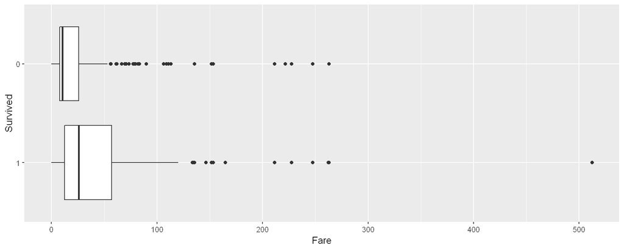

```r
ggplot(aes_string(x='Survived',y='Fare'),data=df[df[['Sample']] == 'train',]) + geom_boxplot() + coord_flip()
```

# Preenchendo o dado faltante (Mr. Thomas Storey)

```r
df[is.na(df[['Fare']]),]
```

A data.frame: 1 × 13

|  | PassengerId <fct> | Survived <fct> | Pclass <ord> | Name <chr> | Sex <fct> | Age <dbl> | SibSp <int> | Parch <int> | Ticket <chr> | Fare <dbl> | Cabin <fct> | Embarked <fct> | Sample <fct> |
| --- | --- | --- | --- | --- | --- | --- | --- | --- | --- | --- | --- | --- | --- |
| 1044 | 1044 | NA | 3 | Storey, Mr. Thomas | male | 60.5 | 0 | 0 | 3701 | NA | NA | S | test |

Uma das técnicas mais rápidas e menos trabalhosas para substituir um dado faltante é a utilização das próprias medidas de posição, apesar de existirem outras técnicas com melhor fundamentação teórica. Considerando que para o caso da variável Fare existe somente um dado faltante, essa técnica foi a escolhida. Além disso, visto que os dados de Fare e Pclass estão negativamente correlacionados, verificou-se o comportamento dessas duas variáveis para que um valor mais lógico pudesse ser utilizado para substituir o dado faltante.

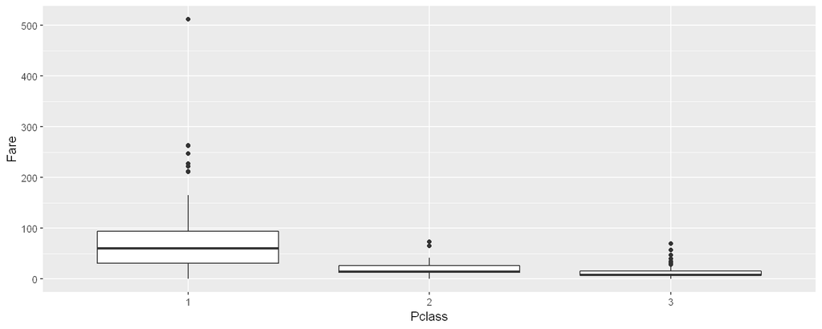

```r
ggplot(aes_string(y='Fare',x='Pclass'),data=df[df[['Sample']] == 'train',]) + geom_boxplot()
```

A medida de posição escolhida foi a mediana. Além disso, como o indivíduo pertence a terceira classe, foi escolhida a mediana da terceira classe para substituir o dado faltante.

```r
df[df[['Sample']] == 'train',] %>%
    group_by(Pclass) %>%
    summarise(summary = list(c(summary(object = Fare)))) %>%
    unnest_wider(summary)
```

A tibble: 3 × 7

| Pclass <ord> | Min. <dbl> | 1st Qu. <dbl> | Median <dbl> | Mean <dbl> | 3rd Qu. <dbl> | Max. <dbl> |
| --- | --- | --- | --- | --- | --- | --- |
| 1 | 0 | 30.92395 | 60.2875 | 84.15468750 | 93.5 | 512.3292 |
| 2 | 0 | 13.00000 | 14.2500 | 20.66218315 | 26.0 | 73.5000 |
| 3 | 0 | 7.75000 | 8.0500 | 13.67555010 | 15.5 | 69.5500 |

```r
df[is.na(df[['Fare']]),'Fare'] <- 8.0500
```

```r
df[is.na(df[['Fare']]),'Fare']
```

```r
df[df[['PassengerId']] == 1044,]
```

A data.frame: 1 × 13

|  | PassengerId <fct> | Survived <fct> | Pclass <ord> | Name <chr> | Sex <fct> | Age <dbl> | SibSp <int> | Parch <int> | Ticket <chr> | Fare <dbl> | Cabin <fct> | Embarked <fct> | Sample <fct> |
| --- | --- | --- | --- | --- | --- | --- | --- | --- | --- | --- | --- | --- | --- |
| 1044 | 1044 | NA | 3 | Storey, Mr. Thomas | male | 60.5 | 0 | 0 | 3701 | 8.05 | NA | S | test |

## Cabin

```r
calcula_tab_frequencia(tabela_de_entrada=df[df[['Sample']] == 'train',],
                        nome_variavel='Cabin',
                        decreasing = TRUE)
```

1. 'Nome da tabela abaixo: table_count_propCabin'

2. A data.frame: 187 × 5

   |  | Category <fct> | Frequency <int> | Percentage <table> | Cumulative.Frequency <int> | Cumulative.Percentage <dbl> |
   | --- | --- | --- | --- | --- | --- |
   | 187 | NA | 687 | 77.10 | 687 | 77.10 |
   | 61 | B96 B98 | 4 | 0.45 | 691 | 77.55 |
   | 81 | C23 C25 C27 | 4 | 0.45 | 695 | 78.00 |
   | 185 | G6 | 4 | 0.45 | 699 | 78.45 |
   | 80 | C22 C26 | 3 | 0.34 | 702 | 78.79 |
   | 118 | D | 3 | 0.34 | 705 | 79.12 |
   | 149 | E101 | 3 | 0.34 | 708 | 79.46 |
   | 181 | F2 | 3 | 0.34 | 711 | 79.80 |
   | ... | ... | ... | ... | ... | ... |
   | 160 | E39 E41 | 0 | 0 | 891 | 100 |
   | 163 | E45 | 0 | 0 | 891 | 100 |
   | 167 | E52 | 0 | 0 | 891 | 100 |
   | 169 | E60 | 0 | 0 | 891 | 100 |
   | 175 | F | 0 | 0 | 891 | 100 |
   | 176 | F E46 | 0 | 0 | 891 | 100 |
   | 177 | F E57 | 0 | 0 | 891 | 100 |

## Survived X Cabin

### Método Optimal Binning - Junção de categorias por métodos automáticos

Dicas para discretização via WOE:

- 1) Todas as categorias calculadas têm pelo menos 5% das observações.
- 2) Todas as categorias calculadas têm valores diferentes de zero para o número de casos bons e ruins.
- 3) Os Woe's são distintos para cada categoria calculada. As categorias calculadas que tinham Woe's semelhantes foram agrupadas.
- 4) Valores ausentes estão em categorias separadas.
- 5) Os Woe's são monotônicos, isto é, estão crescendo ou diminuindo com os agrupamentos. (Recomendação do uso dessa dica é mais fraca do que para as outras dicas).

```r
df[['Survived_BadGod']] <- df[['Survived']]
levels(df[['Survived_BadGod']]) <- c('bad','good') # factor(c('1','0'))
```

```r
bins <- woebin(df[df[['Sample']] == 'train',],
                check_cate_num = FALSE, # usar quando o numero de categorias é > 50
                x='Cabin',
                y='Survived_BadGod',
                method='chimerge')
bins
```

```
[INFO] creating woe binning ...
```

**$Cabin** =

A data.table: 2 × 12

| variable <chr> | bin <chr> | count <int> | count_distr <dbl> | neg <int> | pos <int> | posprob <dbl> | woe <dbl> | bin_iv <dbl> | total_iv <dbl> | breaks <chr> | is_special_values <lgl> |
| --- | --- | --- | --- | --- | --- | --- | --- | --- | --- | --- | --- |
| Cabin | missing | 687 | 0.771043771 | 481 | 206 | 0.2998544396 | -0.3747033969 | 0.1025935099 | 0.4219625092 | missing | TRUE |
| Cabin | A10%,%A14%,%A16%,%A19%,%A20%,%A23%,%A24%,%A26%,%A31%,%A32%,%A34%,%A36%,%A5%,%A6%,%A7%,%B101%,%B102%,%B18%,%B19%,%B20%,%B22%,%B28%,%B3%,%B30%,%B35%,%B37%,%B38%,%B39%,%B4%,%B41%,%B42%,%B49%,%B5%,%B50%,%… | 204 | 0.228956229 | 68 | 136 | 0.6666666667 | 1.1664348850 | 0.3193689993 | 0.4219625092 | A10%,%A14%,%A16%,%A19%,%A20%,%A23%,%A24%,%A26%,%A31%,%A32%,%A34%,%A36%,%A5%,%A6%,%A7%,%B101%,%B102%,%B18%,%B19%,%B20%,%B22%,%B28%,%B3%,%B30%,%B35%,%B37%,%B38%,%B39%,%B4%,%B41%,%B42%,%B49%,%B5%,%B50%,%… | FALSE |

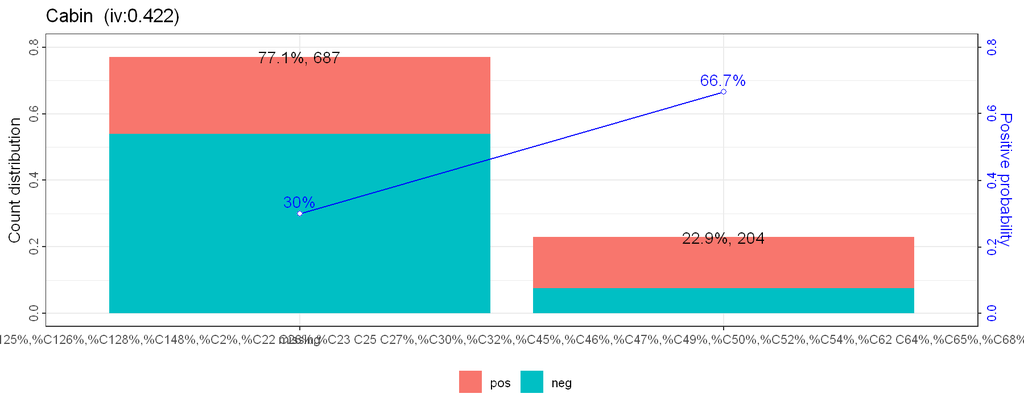

```r
woebin_plot(bins)
```

O método optimal binning da função **woebin** com o argumento **method='chimerge'** apenas dividiu a variável Cabin em duas categorias: missing e não missing. Se é de interesse ter um maior detalhamento da variável em mais categorias, é interessante utilizar o argumento **method='tree'**. Por simplificação, o método **chimerge** foi escolhido.

```r
# df <- woebin_ply(df, bins=bins, to = "bin", print_step = TRUE) # to = "bin" ou to = "woe"
df[['Cabin']] <- as.factor(ifelse(is.na(df[['Cabin']]),NA,'AnyCabin'))
df <- df %>% select(-c('Survived_BadGod'))
df %>% head()
```

A data.frame: 6 × 13

|  | PassengerId <fct> | Survived <fct> | Pclass <ord> | Name <chr> | Sex <fct> | Age <dbl> | SibSp <int> | Parch <int> | Ticket <chr> | Fare <dbl> | Cabin <fct> | Embarked <fct> | Sample <fct> |
| --- | --- | --- | --- | --- | --- | --- | --- | --- | --- | --- | --- | --- | --- |
| 1 | 1 | 0 | 3 | Braund, Mr. Owen Harris | male | 22 | 1 | 0 | A/5 21171 | 7.2500 | NA | S | train |
| 2 | 2 | 1 | 1 | Cumings, Mrs. John Bradley (Florence Briggs Thayer) | female | 38 | 1 | 0 | PC 17599 | 71.2833 | AnyCabin | C | train |
| 3 | 3 | 1 | 3 | Heikkinen, Miss. Laina | female | 26 | 0 | 0 | STON/O2. 3101282 | 7.9250 | NA | S | train |
| 4 | 4 | 1 | 1 | Futrelle, Mrs. Jacques Heath (Lily May Peel) | female | 35 | 1 | 0 | 113803 | 53.1000 | AnyCabin | S | train |
| 5 | 5 | 0 | 3 | Allen, Mr. William Henry | male | 35 | 0 | 0 | 373450 | 8.0500 | NA | S | train |
| 6 | 6 | 0 | 3 | Moran, Mr. James | male | NA | 0 | 0 | 330877 | 8.4583 | NA | Q | train |

## Embarked

```r
calcula_tab_frequencia(tabela_de_entrada=df[df[['Sample']] == 'train',],
                        nome_variavel='Embarked')
```

1. 'Nome da tabela abaixo: table_count_propEmbarked'

2. A data.frame: 4 × 5

   | Category <fct> | Frequency <int> | Percentage <table> | Cumulative.Frequency <int> | Cumulative.Percentage <dbl> |
   | --- | --- | --- | --- | --- |
   | C | 168 | 18.86 | 168 | 18.86 |
   | Q | 77 | 8.64 | 245 | 27.50 |
   | S | 644 | 72.28 | 889 | 99.78 |
   | NA | 2 | 0.22 | 891 | 100.00 |

```r
grafico_tab_frequencia2(table_count_prop=table_count_propEmbarked,
                        nome_variavel='Embarked',
                        cor_grafico='darkred',
                        size=6,tx1=0.15,tx2=1.05,
                        coord_flip=FALSE)
gg_count_propEmbarked <- gg_count_propEmbarked + theme(axis.text=element_text(size=12),
                                            axis.title=element_text(size=12))
gg_count_propEmbarked_plotly1 <- ggplotly(gg_count_propEmbarked)
```

1. 'Nome do gráfico: gg_count_propEmbarked'

```r
htmlwidgets::saveWidget(as_widget(gg_count_propEmbarked_plotly1), "gg_count_propEmbarked_plotly1.html")
IRdisplay::display_html('<iframe src="gg_count_propEmbarked_plotly1.html" width=100%, height=400></iframe>')
```

[interactive chart not shown]

```r
df[is.na(df[['Embarked']]),]
```

A data.frame: 2 × 13

|  | PassengerId <fct> | Survived <fct> | Pclass <ord> | Name <chr> | Sex <fct> | Age <dbl> | SibSp <int> | Parch <int> | Ticket <chr> | Fare <dbl> | Cabin <fct> | Embarked <fct> | Sample <fct> |
| --- | --- | --- | --- | --- | --- | --- | --- | --- | --- | --- | --- | --- | --- |
| 62 | 62 | 1 | 1 | Icard, Miss. Amelie | female | 38 | 0 | 0 | 113572 | 80 | AnyCabin | NA | train |
| 830 | 830 | 1 | 1 | Stone, Mrs. George Nelson (Martha Evelyn) | female | 62 | 0 | 0 | 113572 | 80 | AnyCabin | NA | train |

Intuitivamente, poderia ser utilizado o método de imputação de dados ausentes pela classe mais frequente pois são poucos casos (2 observações). Além disso, em pesquisas pela internet, foi constatado que as duas mulheres embarcaram em Southampton (S). Portanto, faz sentido seguir com esse preenchimento dos dados.

```r
df[is.na(df[['Embarked']]),'Embarked'] <- 'S'
```

```r
df[df[['PassengerId']] %in% c(62,830),]
```

A data.frame: 2 × 13

|  | PassengerId <fct> | Survived <fct> | Pclass <ord> | Name <chr> | Sex <fct> | Age <dbl> | SibSp <int> | Parch <int> | Ticket <chr> | Fare <dbl> | Cabin <fct> | Embarked <fct> | Sample <fct> |
| --- | --- | --- | --- | --- | --- | --- | --- | --- | --- | --- | --- | --- | --- |
| 62 | 62 | 1 | 1 | Icard, Miss. Amelie | female | 38 | 0 | 0 | 113572 | 80 | AnyCabin | S | train |
| 830 | 830 | 1 | 1 | Stone, Mrs. George Nelson (Martha Evelyn) | female | 62 | 0 | 0 | 113572 | 80 | AnyCabin | S | train |

```r
calcula_tab_frequencia(tabela_de_entrada=df[df[['Sample']] == 'train',],
                        nome_variavel='Embarked')
```

1. 'Nome da tabela abaixo: table_count_propEmbarked'

2. A data.frame: 3 × 5

   | Category <fct> | Frequency <int> | Percentage <table> | Cumulative.Frequency <int> | Cumulative.Percentage <dbl> |
   | --- | --- | --- | --- | --- |
   | C | 168 | 18.86 | 168 | 18.86 |
   | Q | 77 | 8.64 | 245 | 27.50 |
   | S | 646 | 72.50 | 891 | 100.00 |

```r
grafico_tab_frequencia2(table_count_prop=table_count_propEmbarked,
                        nome_variavel='Embarked',
                        cor_grafico='darkred',
                        size=6,tx1=0.15,tx2=1.05,
                        coord_flip=FALSE)
gg_count_propEmbarked <- gg_count_propEmbarked + theme(axis.text=element_text(size=12),
                                            axis.title=element_text(size=12))
gg_count_propEmbarked_plotly2 <- ggplotly(gg_count_propEmbarked)
```

1. 'Nome do gráfico: gg_count_propEmbarked'

```r
htmlwidgets::saveWidget(as_widget(gg_count_propEmbarked_plotly2), "gg_count_propEmbarked_plotly2.html")
IRdisplay::display_html('<iframe src="gg_count_propEmbarked_plotly2.html" width=100%, height=400></iframe>')
```

[interactive chart not shown]

## Survived X Embarked

```r
calcula_tab_frequencia_bivariada(tabela_de_entrada=df[df[['Sample']] == 'train',],
                                 nome_variavel1='Survived',
                                 nome_variavel2='Embarked')
```

1. 'Nome da tabela abaixo: table_count_propSurvived_Embarked'

2. A data.frame: 6 × 8

   | Survived <fct> | Embarked <fct> | Frequency <int> | sum_x <int> | cumsum_sum_x <int> | percentage_sum_x <dbl> | Frequency_div_sum_x <dbl> | percentage_Frequency_div_sum_x <dbl> |
   | --- | --- | --- | --- | --- | --- | --- | --- |
   | 1 | C | 93 | 168 | 168 | 18.9 | 0.5535714286 | 55.4 |
   | 0 | C | 75 | 168 | 168 | 18.9 | 0.4464285714 | 44.6 |
   | 1 | Q | 30 | 77 | 245 | 8.6 | 0.3896103896 | 39.0 |
   | 0 | Q | 47 | 77 | 245 | 8.6 | 0.6103896104 | 61.0 |
   | 1 | S | 219 | 646 | 891 | 72.5 | 0.3390092879 | 33.9 |
   | 0 | S | 427 | 646 | 891 | 72.5 | 0.6609907121 | 66.1 |

```r
grafico_tab_frequencia_bivariada2(table_count_prop=table_count_propSurvived_Embarked,
                                  nome_variavel1='Survived',
                                  nome_variavel2='Embarked',
                                  tx1=0.2,tx2=0,size=6,
                                  legend=TRUE,percentage=TRUE,count=TRUE)

gg_count_propSurvived_Embarked <- gg_count_propSurvived_Embarked + theme(axis.text=element_text(size=12),
                                                                axis.title=element_text(size=15),
                                                                legend.title=element_text(size=15),
                                                                legend.text=element_text(size=15)) +
                                                                scale_fill_brewer(palette="Set2")
gg_count_propSurvived_Embarked_plotly1 <- ggplotly(gg_count_propSurvived_Embarked)
```

```
[1] "Para retirar as porcentagens, use legend = FALSE ou size = 0!"
```

1. 'Nome do gráfico: gg_count_propSurvived_Embarked'

```r
htmlwidgets::saveWidget(as_widget(gg_count_propSurvived_Embarked_plotly1), "gg_count_propSurvived_Embarked_plotly1.html")
IRdisplay::display_html('<iframe src="gg_count_propSurvived_Embarked_plotly1.html" width=100%, height=400></iframe>')
```

[interactive chart not shown]

```r
grafico_tab_frequencia_bivariada3(table_count_prop=table_count_propSurvived_Embarked,
                                  nome_variavel1='Survived',
                                  nome_variavel2='Embarked',
                                  size=6,tx=0,legend=TRUE)
gg_count_propSurvived_Embarked <- gg_count_propSurvived_Embarked + theme(axis.text=element_text(size=12),
                                                                axis.title=element_text(size=15),
                                                                legend.title=element_text(size=15),
                                                                legend.text=element_text(size=15)) +
                                                                scale_fill_brewer(palette="Set2")
gg_count_propSurvived_Embarked_plotly2 <- ggplotly(gg_count_propSurvived_Embarked)
```

1. 'Nome do gráfico: gg_count_propSurvived_Embarked'

```r
htmlwidgets::saveWidget(as_widget(gg_count_propSurvived_Embarked_plotly2), "gg_count_propSurvived_Embarked_plotly2.html")
IRdisplay::display_html('<iframe src="gg_count_propSurvived_Embarked_plotly2.html" width=100%, height=400></iframe>')
```

[interactive chart not shown]

## Age

```r
binning_quantities(dados_entrada=df[df[['Sample']] == 'train',],
                    nome_variavel='Age',
                    method='Sturges')
```

1. 'Nome da lista: lista_Age'

2. **$k**

   11

   **$limites_intervalos**

   1. -Inf

   2. 7.65

   3. 14.9

   4. 22.1

   5. 29.4

   6. 36.6

   7. 43.8

   8. 51.1

   9. 58.3

   10. 65.5

   11. 72.8

   12. Inf

   **$dados_saida**

   2. (36.6,43.8]

   3. (22.1,29.4]

   4. (29.4,36.6]

   5. (29.4,36.6]

   6. <NA>

   7. (51.1,58.3]

   8. (-Inf,7.65]

   9. (22.1,29.4]

   10. (7.65,14.9]

   11. (-Inf,7.65]

   12. (51.1,58.3]

   13. (14.9,22.1]

   14. (36.6,43.8]

   15. (7.65,14.9]

   16. (51.1,58.3]

   17. (-Inf,7.65]

   18. <NA>

   19. (29.4,36.6]

   20. <NA>

   21. (29.4,36.6]

   22. (29.4,36.6]

   23. (14.9,22.1]

   24. (22.1,29.4]

   25. (7.65,14.9]

   26. (36.6,43.8]

   27. <NA>

   28. (14.9,22.1]

   29. <NA>

   30. <NA>

   31. (36.6,43.8]

   32. <NA>

   33. <NA>

   34. (65.5,72.8]

   35. (22.1,29.4]

   36. (36.6,43.8]

   37. <NA>

   38. (14.9,22.1]

   39. (14.9,22.1]

   40. (7.65,14.9]

   41. (36.6,43.8]

   42. (22.1,29.4]

   43. <NA>

   44. (-Inf,7.65]

   45. (14.9,22.1]

   46. <NA>

   47. <NA>

   48. <NA>

   49. <NA>

   50. (14.9,22.1]

   51. (-Inf,7.65]

   52. (14.9,22.1]

   53. (43.8,51.1]

   54. (22.1,29.4]

   55. (58.3,65.5]

   56. <NA>

   57. (14.9,22.1]

   58. (22.1,29.4]

   59. (-Inf,7.65]

   60. (7.65,14.9]

   61. (14.9,22.1]

   62. (36.6,43.8]

   63. (43.8,51.1]

   64. (-Inf,7.65]

   65. <NA>

   66. <NA>

   67. (22.1,29.4]

   68. (14.9,22.1]

   69. (14.9,22.1]

   70. (22.1,29.4]

   71. (29.4,36.6]

   72. (14.9,22.1]

   73. (14.9,22.1]

   74. (22.1,29.4]

   75. (29.4,36.6]

   76. (22.1,29.4]

   77. <NA>

   78. <NA>

   79. (-Inf,7.65]

   80. (29.4,36.6]

   81. (14.9,22.1]

   82. (22.1,29.4]

   83. <NA>

   84. (22.1,29.4]

   85. (14.9,22.1]

   86. (29.4,36.6]

   87. (14.9,22.1]

   88. <NA>

   89. (22.1,29.4]

   90. (22.1,29.4]

   91. (22.1,29.4]

   92. (14.9,22.1]

   93. (43.8,51.1]

   94. (22.1,29.4]

   95. (58.3,65.5]

   96. <NA>

   97. (65.5,72.8]

   98. (22.1,29.4]

   99. (29.4,36.6]

   100. (29.4,36.6]

   101. (22.1,29.4]

   102. <NA>

   103. (14.9,22.1]

   104. (29.4,36.6]

   105. (36.6,43.8]

   106. (22.1,29.4]

   107. (14.9,22.1]

   108. <NA>

   109. (36.6,43.8]

   110. <NA>

   111. (43.8,51.1]

   112. (7.65,14.9]

   113. (14.9,22.1]

   114. (14.9,22.1]

   115. (14.9,22.1]

   116. (14.9,22.1]

   117. (65.5,72.8]

   118. (22.1,29.4]

   119. (22.1,29.4]

   120. (-Inf,7.65]

   121. (14.9,22.1]

   122. <NA>

   123. (29.4,36.6]

   124. (29.4,36.6]

   125. (51.1,58.3]

   126. (7.65,14.9]

   127. <NA>

   128. (22.1,29.4]

   129. <NA>

   130. (43.8,51.1]

   131. (29.4,36.6]

   132. (14.9,22.1]

   133. (43.8,51.1]

   134. (22.1,29.4]

   135. (22.1,29.4]

   136. (22.1,29.4]

   137. (14.9,22.1]

   138. (36.6,43.8]

   139. (14.9,22.1]

   140. (22.1,29.4]

   141. <NA>

   142. (14.9,22.1]

   143. (22.1,29.4]

   144. (14.9,22.1]

   145. (14.9,22.1]

   146. (14.9,22.1]

   147. (22.1,29.4]

   148. (7.65,14.9]

   149. (29.4,36.6]

   150. (36.6,43.8]

   151. (43.8,51.1]

   152. (14.9,22.1]

   153. (51.1,58.3]

   154. (36.6,43.8]

   155. <NA>

   156. (43.8,51.1]

   157. (14.9,22.1]

   158. (29.4,36.6]

   159. <NA>

   160. <NA>

   161. (43.8,51.1]

   162. (36.6,43.8]

   163. (22.1,29.4]

   164. (14.9,22.1]

   165. (-Inf,7.65]

   166. (7.65,14.9]

   167. <NA>

   168. (43.8,51.1]

   169. <NA>

   170. (22.1,29.4]

   171. (58.3,65.5]

   172. (-Inf,7.65]

   173. (-Inf,7.65]

   174. (14.9,22.1]

   175. (51.1,58.3]

   176. (14.9,22.1]

   177. <NA>

   178. (43.8,51.1]

   179. (29.4,36.6]

   180. (29.4,36.6]

   181. <NA>

   182. <NA>

   183. (7.65,14.9]

   184. (-Inf,7.65]

   185. (-Inf,7.65]

   186. <NA>

   187. <NA>

   188. (43.8,51.1]

   189. (36.6,43.8]

   190. (29.4,36.6]

   191. (29.4,36.6]

   192. (14.9,22.1]

   193. (14.9,22.1]

   194. (-Inf,7.65]

   195. (43.8,51.1]

   196. (51.1,58.3]

   197. <NA>

   198. (36.6,43.8]

   199. <NA>

   200. (22.1,29.4]

   201. ...

   202. (-Inf,7.65]

   203. <NA>

   204. (22.1,29.4]

   205. (58.3,65.5]

   206. (51.1,58.3]

   207. (43.8,51.1]

   208. <NA>

   209. (43.8,51.1]

   210. (36.6,43.8]

   211. (14.9,22.1]

   212. (29.4,36.6]

   213. (14.9,22.1]

   214. (22.1,29.4]

   215. (22.1,29.4]

   216. (36.6,43.8]

   217. (43.8,51.1]

   218. (36.6,43.8]

   219. (14.9,22.1]

   220. <NA>

   221. (22.1,29.4]

   222. <NA>

   223. (43.8,51.1]

   224. (22.1,29.4]

   225. (51.1,58.3]

   226. (14.9,22.1]

   227. (36.6,43.8]

   228. (22.1,29.4]

   229. <NA>

   230. (29.4,36.6]

   231. (-Inf,7.65]

   232. (14.9,22.1]

   233. (29.4,36.6]

   234. (43.8,51.1]

   235. (22.1,29.4]

   236. (14.9,22.1]

   237. (29.4,36.6]

   238. <NA>

   239. (22.1,29.4]

   240. (22.1,29.4]

   241. (22.1,29.4]

   242. (7.65,14.9]

   243. <NA>

   244. (22.1,29.4]

   245. (22.1,29.4]

   246. (22.1,29.4]

   247. (43.8,51.1]

   248. (29.4,36.6]

   249. <NA>

   250. <NA>

   251. <NA>

   252. (29.4,36.6]

   253. (14.9,22.1]

   254. (22.1,29.4]

   255. (29.4,36.6]

   256. (65.5,72.8]

   257. (14.9,22.1]

   258. (29.4,36.6]

   259. (14.9,22.1]

   260. (29.4,36.6]

   261. (-Inf,7.65]

   262. (-Inf,7.65]

   263. (29.4,36.6]

   264. (22.1,29.4]

   265. (43.8,51.1]

   266. (-Inf,7.65]

   267. (22.1,29.4]

   268. (14.9,22.1]

   269. (29.4,36.6]

   270. (29.4,36.6]

   271. <NA>

   272. (36.6,43.8]

   273. (14.9,22.1]

   274. (29.4,36.6]

   275. (14.9,22.1]

   276. (43.8,51.1]

   277. <NA>

   278. (29.4,36.6]

   279. <NA>

   280. (29.4,36.6]

   281. (22.1,29.4]

   282. (43.8,51.1]

   283. (51.1,58.3]

   284. <NA>

   285. (51.1,58.3]

   286. (14.9,22.1]

   287. <NA>

   288. (-Inf,7.65]

   289. <NA>

   290. (36.6,43.8]

   291. (7.65,14.9]

   292. (14.9,22.1]

   293. (22.1,29.4]

   294. <NA>

   295. (22.1,29.4]

   296. (22.1,29.4]

   297. (14.9,22.1]

   298. (7.65,14.9]

   299. (-Inf,7.65]

   300. (43.8,51.1]

   301. <NA>

   302. (14.9,22.1]

   303. <NA>

   304. <NA>

   305. (22.1,29.4]

   306. (36.6,43.8]

   307. (43.8,51.1]

   308. (29.4,36.6]

   309. (29.4,36.6]

   310. (29.4,36.6]

   311. (29.4,36.6]

   312. (29.4,36.6]

   313. (7.65,14.9]

   314. (-Inf,7.65]

   315. (22.1,29.4]

   316. (29.4,36.6]

   317. (36.6,43.8]

   318. (14.9,22.1]

   319. (36.6,43.8]

   320. (29.4,36.6]

   321. (22.1,29.4]

   322. (36.6,43.8]

   323. (29.4,36.6]

   324. (-Inf,7.65]

   325. (29.4,36.6]

   326. <NA>

   327. (22.1,29.4]

   328. (29.4,36.6]

   329. (36.6,43.8]

   330. (7.65,14.9]

   331. (51.1,58.3]

   332. (22.1,29.4]

   333. (36.6,43.8]

   334. (22.1,29.4]

   335. (-Inf,7.65]

   336. <NA>

   337. <NA>

   338. (-Inf,7.65]

   339. <NA>

   340. (58.3,65.5]

   341. (14.9,22.1]

   342. (-Inf,7.65]

   343. <NA>

   344. (22.1,29.4]

   345. (14.9,22.1]

   346. (36.6,43.8]

   347. (14.9,22.1]

   348. <NA>

   349. (29.4,36.6]

   350. <NA>

   351. (14.9,22.1]

   352. (14.9,22.1]

   353. (29.4,36.6]

   354. (29.4,36.6]

   355. (14.9,22.1]

   356. (36.6,43.8]

   357. <NA>

   358. (29.4,36.6]

   359. (22.1,29.4]

   360. <NA>

   361. (-Inf,7.65]

   362. (72.8,Inf),

   363. (7.65,14.9]

   364. (14.9,22.1]

   365. (43.8,51.1]

   366. (14.9,22.1]

   367. (43.8,51.1]

   368. (43.8,51.1]

   369. (22.1,29.4]

   370. <NA>

   371. (36.6,43.8]

   372. (14.9,22.1]

   373. (43.8,51.1]

   374. <NA>

   375. (22.1,29.4]

   376. (36.6,43.8]

   377. (22.1,29.4]

   378. (29.4,36.6]

   379. <NA>

   380. (-Inf,7.65]

   381. (22.1,29.4]

   382. (43.8,51.1]

   383. (29.4,36.6]

   384. (43.8,51.1]

   385. (22.1,29.4]

   386. (14.9,22.1]

   387. (14.9,22.1]

   388. (14.9,22.1]

   389. <NA>

   390. (51.1,58.3]

   391. (22.1,29.4]

   392. (29.4,36.6]

   393. (14.9,22.1]

   394. (22.1,29.4]

   395. (22.1,29.4]

   396. (36.6,43.8]

   397. (22.1,29.4]

   398. (14.9,22.1]

   399. <NA>

   400. (22.1,29.4]

   401. (29.4,36.6]

   **Levels**:**

   1. '(-Inf,7.65]'

   2. '(7.65,14.9]'

   3. '(14.9,22.1]'

   4. '(22.1,29.4]'

   5. '(29.4,36.6]'

   6. '(36.6,43.8]'

   7. '(43.8,51.1]'

   8. '(51.1,58.3]'

   9. '(58.3,65.5]'

   10. '(65.5,72.8]'

   11. '(72.8,Inf),'

```r
df[df[['Sample']] == 'train','Age_binning'] <- lista_Age[['dados_saida']]
calcula_tab_frequencia(tabela_de_entrada=df[df[['Sample']] == 'train',],
                        nome_variavel='Age_binning')
```

1. 'Nome da tabela abaixo: table_count_propAge_binning'

2. A data.frame: 12 × 5

   | Category <fct> | Frequency <int> | Percentage <table> | Cumulative.Frequency <int> | Cumulative.Percentage <dbl> |
   | --- | --- | --- | --- | --- |
   | (-Inf,7.65] | 50 | 5.61 | 50 | 5.61 |
   | (7.65,14.9] | 28 | 3.14 | 78 | 8.75 |
   | (14.9,22.1] | 153 | 17.17 | 231 | 25.93 |
   | (22.1,29.4] | 153 | 17.17 | 384 | 43.10 |
   | (29.4,36.6] | 136 | 15.26 | 520 | 58.36 |
   | (36.6,43.8] | 70 | 7.86 | 590 | 66.22 |
   | (43.8,51.1] | 67 | 7.52 | 657 | 73.74 |
   | (51.1,58.3] | 29 | 3.25 | 686 | 76.99 |
   | (58.3,65.5] | 20 | 2.24 | 706 | 79.24 |
   | (65.5,72.8] | 6 | 0.67 | 712 | 79.91 |
   | (72.8,Inf), | 2 | 0.22 | 714 | 80.13 |
   | NA | 177 | 19.87 | 891 | 100.00 |

1. 'Nome do gráfico: gg_count_propAge_binning'

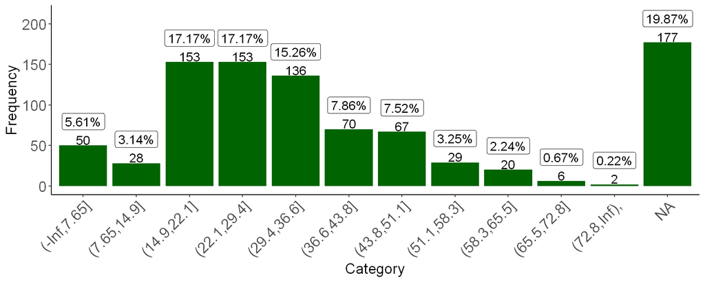

```r
grafico_tab_frequencia3(table_count_prop=table_count_propAge_binning,
                       nome_variavel='Age_binning',
                       cor_grafico='darkgreen',
                       size=4.5,
                       angle=45,tx1=0.4,tx2=1.2,
                       legend=TRUE,percentage=TRUE,count=TRUE)
gg_count_propAge_binning <- gg_count_propAge_binning + theme(axis.text=element_text(size=15),
                                                            axis.title=element_text(size=15))
gg_count_propAge_binning
```

```r
df <- select(df,-c('Age_binning')) # drop column Age_binning
```

O gráfico mostra que aproximadamente 19,87% dos indivíduos não tiveram as suas idades registradas. Portanto, há presença de dados ausentes e isso pode gerar predições ruins se não for tratado adequadamente. Uma das abordagens a ser utilizada seria a discretização da variável Age, o que permitiria a separação da categoria NA em uma categoria separada. Como isso já foi feito na resolução em Python, utilizamos uma outra abordagem que é conhecida na literatura como Imputação de Dados Ausentes.

Acreditamos que o mecanismo gerador dos dados é MCAR (Missing Completely at Random). Duas abordagens foram utilizadas:

- 1) Substituição dos dados faltantes pela mediana;
- 2) Utilização do pacote mice.

### 1 - Substituição dos dados faltantes pela mediana;

```r
df[['Age_t_missing']] <- df[['Age']]
df[df[['Sample']] == 'train' & is.na(df[['Age']]),'Age_t_missing'] <- round(median(df[df[['Sample']] == 'train','Age'], na.rm = T), 2)
```

```r
round(median(df[df[['Sample']] == 'train','Age'], na.rm = T), 2)
```

28

```r
apply_binning_by_limites_intervalos(limites_intervalos=lista_Age$limites_intervalos,
                                    dados_entrada=df[df[['Sample']] == 'train',],
                                    nome_variavel='Age_t_missing')
```

1. 'Nome da lista: lista_Age_t_missing'

2. **$k**

   11

   **$limites_intervalos**

   1. -Inf

   2. 7.65

   3. 14.9

   4. 22.1

   5. 29.4

   6. 36.6

   7. 43.8

   8. 51.1

   9. 58.3

   10. 65.5

   11. 72.8

   12. Inf

   **$dados_saida**

   2. (36.6,43.8]

   3. (22.1,29.4]

   4. (29.4,36.6]

   5. (29.4,36.6]

   6. (22.1,29.4]

   7. (51.1,58.3]

   8. [-Inf,7.65]

   9. (22.1,29.4]

   10. (7.65,14.9]

   11. [-Inf,7.65]

   12. (51.1,58.3]

   13. (14.9,22.1]

   14. (36.6,43.8]

   15. (7.65,14.9]

   16. (51.1,58.3]

   17. [-Inf,7.65]

   18. (22.1,29.4]

   19. (29.4,36.6]

   20. (22.1,29.4]

   21. (29.4,36.6]

   22. (29.4,36.6]

   23. (14.9,22.1]

   24. (22.1,29.4]

   25. (7.65,14.9]

   26. (36.6,43.8]

   27. (22.1,29.4]

   28. (14.9,22.1]

   29. (22.1,29.4]

   30. (22.1,29.4]

   31. (36.6,43.8]

   32. (22.1,29.4]

   33. (22.1,29.4]

   34. (65.5,72.8]

   35. (22.1,29.4]

   36. (36.6,43.8]

   37. (22.1,29.4]

   38. (14.9,22.1]

   39. (14.9,22.1]

   40. (7.65,14.9]

   41. (36.6,43.8]

   42. (22.1,29.4]

   43. (22.1,29.4]

   44. [-Inf,7.65]

   45. (14.9,22.1]

   46. (22.1,29.4]

   47. (22.1,29.4]

   48. (22.1,29.4]

   49. (22.1,29.4]

   50. (14.9,22.1]

   51. [-Inf,7.65]

   52. (14.9,22.1]

   53. (43.8,51.1]

   54. (22.1,29.4]

   55. (58.3,65.5]

   56. (22.1,29.4]

   57. (14.9,22.1]

   58. (22.1,29.4]

   59. [-Inf,7.65]

   60. (7.65,14.9]

   61. (14.9,22.1]

   62. (36.6,43.8]

   63. (43.8,51.1]

   64. [-Inf,7.65]

   65. (22.1,29.4]

   66. (22.1,29.4]

   67. (22.1,29.4]

   68. (14.9,22.1]

   69. (14.9,22.1]

   70. (22.1,29.4]

   71. (29.4,36.6]

   72. (14.9,22.1]

   73. (14.9,22.1]

   74. (22.1,29.4]

   75. (29.4,36.6]

   76. (22.1,29.4]

   77. (22.1,29.4]

   78. (22.1,29.4]

   79. [-Inf,7.65]

   80. (29.4,36.6]

   81. (14.9,22.1]

   82. (22.1,29.4]

   83. (22.1,29.4]

   84. (22.1,29.4]

   85. (14.9,22.1]

   86. (29.4,36.6]

   87. (14.9,22.1]

   88. (22.1,29.4]

   89. (22.1,29.4]

   90. (22.1,29.4]

   91. (22.1,29.4]

   92. (14.9,22.1]

   93. (43.8,51.1]

   94. (22.1,29.4]

   95. (58.3,65.5]

   96. (22.1,29.4]

   97. (65.5,72.8]

   98. (22.1,29.4]

   99. (29.4,36.6]

   100. (29.4,36.6]

   101. (22.1,29.4]

   102. (22.1,29.4]

   103. (14.9,22.1]

   104. (29.4,36.6]

   105. (36.6,43.8]

   106. (22.1,29.4]

   107. (14.9,22.1]

   108. (22.1,29.4]

   109. (36.6,43.8]

   110. (22.1,29.4]

   111. (43.8,51.1]

   112. (7.65,14.9]

   113. (14.9,22.1]

   114. (14.9,22.1]

   115. (14.9,22.1]

   116. (14.9,22.1]

   117. (65.5,72.8]

   118. (22.1,29.4]

   119. (22.1,29.4]

   120. [-Inf,7.65]

   121. (14.9,22.1]

   122. (22.1,29.4]

   123. (29.4,36.6]

   124. (29.4,36.6]

   125. (51.1,58.3]

   126. (7.65,14.9]

   127. (22.1,29.4]

   128. (22.1,29.4]

   129. (22.1,29.4]

   130. (43.8,51.1]

   131. (29.4,36.6]

   132. (14.9,22.1]

   133. (43.8,51.1]

   134. (22.1,29.4]

   135. (22.1,29.4]

   136. (22.1,29.4]

   137. (14.9,22.1]

   138. (36.6,43.8]

   139. (14.9,22.1]

   140. (22.1,29.4]

   141. (22.1,29.4]

   142. (14.9,22.1]

   143. (22.1,29.4]

   144. (14.9,22.1]

   145. (14.9,22.1]

   146. (14.9,22.1]

   147. (22.1,29.4]

   148. (7.65,14.9]

   149. (29.4,36.6]

   150. (36.6,43.8]

   151. (43.8,51.1]

   152. (14.9,22.1]

   153. (51.1,58.3]

   154. (36.6,43.8]

   155. (22.1,29.4]

   156. (43.8,51.1]

   157. (14.9,22.1]

   158. (29.4,36.6]

   159. (22.1,29.4]

   160. (22.1,29.4]

   161. (43.8,51.1]

   162. (36.6,43.8]

   163. (22.1,29.4]

   164. (14.9,22.1]

   165. [-Inf,7.65]

   166. (7.65,14.9]

   167. (22.1,29.4]

   168. (43.8,51.1]

   169. (22.1,29.4]

   170. (22.1,29.4]

   171. (58.3,65.5]

   172. [-Inf,7.65]

   173. [-Inf,7.65]

   174. (14.9,22.1]

   175. (51.1,58.3]

   176. (14.9,22.1]

   177. (22.1,29.4]

   178. (43.8,51.1]

   179. (29.4,36.6]

   180. (29.4,36.6]

   181. (22.1,29.4]

   182. (22.1,29.4]

   183. (7.65,14.9]

   184. [-Inf,7.65]

   185. [-Inf,7.65]

   186. (22.1,29.4]

   187. (22.1,29.4]

   188. (43.8,51.1]

   189. (36.6,43.8]

   190. (29.4,36.6]

   191. (29.4,36.6]

   192. (14.9,22.1]

   193. (14.9,22.1]

   194. [-Inf,7.65]

   195. (43.8,51.1]

   196. (51.1,58.3]

   197. (22.1,29.4]

   198. (36.6,43.8]

   199. (22.1,29.4]

   200. (22.1,29.4]

   201. ...

   202. [-Inf,7.65]

   203. (22.1,29.4]

   204. (22.1,29.4]

   205. (58.3,65.5]

   206. (51.1,58.3]

   207. (43.8,51.1]

   208. (22.1,29.4]

   209. (43.8,51.1]

   210. (36.6,43.8]

   211. (14.9,22.1]

   212. (29.4,36.6]

   213. (14.9,22.1]

   214. (22.1,29.4]

   215. (22.1,29.4]

   216. (36.6,43.8]

   217. (43.8,51.1]

   218. (36.6,43.8]

   219. (14.9,22.1]

   220. (22.1,29.4]

   221. (22.1,29.4]

   222. (22.1,29.4]

   223. (43.8,51.1]

   224. (22.1,29.4]

   225. (51.1,58.3]

   226. (14.9,22.1]

   227. (36.6,43.8]

   228. (22.1,29.4]

   229. (22.1,29.4]

   230. (29.4,36.6]

   231. [-Inf,7.65]

   232. (14.9,22.1]

   233. (29.4,36.6]

   234. (43.8,51.1]

   235. (22.1,29.4]

   236. (14.9,22.1]

   237. (29.4,36.6]

   238. (22.1,29.4]

   239. (22.1,29.4]

   240. (22.1,29.4]

   241. (22.1,29.4]

   242. (7.65,14.9]

   243. (22.1,29.4]

   244. (22.1,29.4]

   245. (22.1,29.4]

   246. (22.1,29.4]

   247. (43.8,51.1]

   248. (29.4,36.6]

   249. (22.1,29.4]

   250. (22.1,29.4]

   251. (22.1,29.4]

   252. (29.4,36.6]

   253. (14.9,22.1]

   254. (22.1,29.4]

   255. (29.4,36.6]

   256. (65.5,72.8]

   257. (14.9,22.1]

   258. (29.4,36.6]

   259. (14.9,22.1]

   260. (29.4,36.6]

   261. [-Inf,7.65]

   262. [-Inf,7.65]

   263. (29.4,36.6]

   264. (22.1,29.4]

   265. (43.8,51.1]

   266. [-Inf,7.65]

   267. (22.1,29.4]

   268. (14.9,22.1]

   269. (29.4,36.6]

   270. (29.4,36.6]

   271. (22.1,29.4]

   272. (36.6,43.8]